# Project: Investigate a Dataset (TMDb Movie Dataset!)

- Introduction
- Data Wrangling
- Exploratory Data Analysis
- Conclusions

## Introduction

> In this project of **Investigate a Dataset**,I am investigating the *TMDb Movie Dataset* which consists of more than 10,000 entries of movies,their budgets,revenues,cast and other important details. Lets take a look at some of the entries.

```python
import pandas as pd
import numpy as np
import matplotlib.pyplot as plt
import csv
from datetime import datetime
% matplotlib inline
```

```python
tmdb = {}
tmdb = pd.read_csv('tmdb-movies.csv')
tmdb
```

|  | id | imdb_id | popularity | budget | revenue | original_title | cast | homepage | director | tagline | ... | overview | runtime | genres | production_companies | release_date | vote_count | vote_average | release_year | budget_adj | revenue_adj |
| --- | --- | --- | --- | --- | --- | --- | --- | --- | --- | --- | --- | --- | --- | --- | --- | --- | --- | --- | --- | --- | --- |
| 0 | 135397 | tt0369610 | 32.985763 | 150000000 | 1513528810 | Jurassic World | Chris Pratt\|Bryce Dallas Howard\|Irrfan Khan\|Vi... | http://www.jurassicworld.com/ | Colin Trevorrow | The park is open. | ... | Twenty-two years after the events of Jurassic ... | 124 | Action\|Adventure\|Science Fiction\|Thriller | Universal Studios\|Amblin Entertainment\|Legenda... | 6/9/15 | 5562 | 6.5 | 2015 | 1.379999e+08 | 1.392446e+09 |
| 1 | 76341 | tt1392190 | 28.419936 | 150000000 | 378436354 | Mad Max: Fury Road | Tom Hardy\|Charlize Theron\|Hugh Keays-Byrne\|Nic... | http://www.madmaxmovie.com/ | George Miller | What a Lovely Day. | ... | An apocalyptic story set in the furthest reach... | 120 | Action\|Adventure\|Science Fiction\|Thriller | Village Roadshow Pictures\|Kennedy Miller Produ... | 5/13/15 | 6185 | 7.1 | 2015 | 1.379999e+08 | 3.481613e+08 |
| 2 | 262500 | tt2908446 | 13.112507 | 110000000 | 295238201 | Insurgent | Shailene Woodley\|Theo James\|Kate Winslet\|Ansel... | http://www.thedivergentseries.movie/#insurgent | Robert Schwentke | One Choice Can Destroy You | ... | Beatrice Prior must confront her inner demons ... | 119 | Adventure\|Science Fiction\|Thriller | Summit Entertainment\|Mandeville Films\|Red Wago... | 3/18/15 | 2480 | 6.3 | 2015 | 1.012000e+08 | 2.716190e+08 |
| 3 | 140607 | tt2488496 | 11.173104 | 200000000 | 2068178225 | Star Wars: The Force Awakens | Harrison Ford\|Mark Hamill\|Carrie Fisher\|Adam D... | http://www.starwars.com/films/star-wars-episod... | J.J. Abrams | Every generation has a story. | ... | Thirty years after defeating the Galactic Empi... | 136 | Action\|Adventure\|Science Fiction\|Fantasy | Lucasfilm\|Truenorth Productions\|Bad Robot | 12/15/15 | 5292 | 7.5 | 2015 | 1.839999e+08 | 1.902723e+09 |
| 4 | 168259 | tt2820852 | 9.335014 | 190000000 | 1506249360 | Furious 7 | Vin Diesel\|Paul Walker\|Jason Statham\|Michelle ... | http://www.furious7.com/ | James Wan | Vengeance Hits Home | ... | Deckard Shaw seeks revenge against Dominic Tor... | 137 | Action\|Crime\|Thriller | Universal Pictures\|Original Film\|Media Rights ... | 4/1/15 | 2947 | 7.3 | 2015 | 1.747999e+08 | 1.385749e+09 |
| 5 | 281957 | tt1663202 | 9.110700 | 135000000 | 532950503 | The Revenant | Leonardo DiCaprio\|Tom Hardy\|Will Poulter\|Domhn... | http://www.foxmovies.com/movies/the-revenant | Alejandro González Iñárritu | (n. One who has returned, as if from the dead.) | ... | In the 1820s, a frontiersman, Hugh Glass, sets... | 156 | Western\|Drama\|Adventure\|Thriller | Regency Enterprises\|Appian Way\|CatchPlay\|Anony... | 12/25/15 | 3929 | 7.2 | 2015 | 1.241999e+08 | 4.903142e+08 |
| 6 | 87101 | tt1340138 | 8.654359 | 155000000 | 440603537 | Terminator Genisys | Arnold Schwarzenegger\|Jason Clarke\|Emilia Clar... | http://www.terminatormovie.com/ | Alan Taylor | Reset the future | ... | The year is 2029. John Connor, leader of the r... | 125 | Science Fiction\|Action\|Thriller\|Adventure | Paramount Pictures\|Skydance Productions | 6/23/15 | 2598 | 5.8 | 2015 | 1.425999e+08 | 4.053551e+08 |
| 7 | 286217 | tt3659388 | 7.667400 | 108000000 | 595380321 | The Martian | Matt Damon\|Jessica Chastain\|Kristen Wiig\|Jeff ... | http://www.foxmovies.com/movies/the-martian | Ridley Scott | Bring Him Home | ... | During a manned mission to Mars, Astronaut Mar... | 141 | Drama\|Adventure\|Science Fiction | Twentieth Century Fox Film Corporation\|Scott F... | 9/30/15 | 4572 | 7.6 | 2015 | 9.935996e+07 | 5.477497e+08 |
| 8 | 211672 | tt2293640 | 7.404165 | 74000000 | 1156730962 | Minions | Sandra Bullock\|Jon Hamm\|Michael Keaton\|Allison... | http://www.minionsmovie.com/ | Kyle Balda\|Pierre Coffin | Before Gru, they had a history of bad bosses | ... | Minions Stuart, Kevin and Bob are recruited by... | 91 | Family\|Animation\|Adventure\|Comedy | Universal Pictures\|Illumination Entertainment | 6/17/15 | 2893 | 6.5 | 2015 | 6.807997e+07 | 1.064192e+09 |
| 9 | 150540 | tt2096673 | 6.326804 | 175000000 | 853708609 | Inside Out | Amy Poehler\|Phyllis Smith\|Richard Kind\|Bill Ha... | http://movies.disney.com/inside-out | Pete Docter | Meet the little voices inside your head. | ... | Growing up can be a bumpy road, and it's no ex... | 94 | Comedy\|Animation\|Family | Walt Disney Pictures\|Pixar Animation Studios\|W... | 6/9/15 | 3935 | 8.0 | 2015 | 1.609999e+08 | 7.854116e+08 |
| 10 | 206647 | tt2379713 | 6.200282 | 245000000 | 880674609 | Spectre | Daniel Craig\|Christoph Waltz\|Léa Seydoux\|Ralp... | http://www.sonypictures.com/movies/spectre/ | Sam Mendes | A Plan No One Escapes | ... | A cryptic message from Bond’s past sends him... | 148 | Action\|Adventure\|Crime | Columbia Pictures\|Danjaq\|B24 | 10/26/15 | 3254 | 6.2 | 2015 | 2.253999e+08 | 8.102203e+08 |
| 11 | 76757 | tt1617661 | 6.189369 | 176000003 | 183987723 | Jupiter Ascending | Mila Kunis\|Channing Tatum\|Sean Bean\|Eddie Redm... | http://www.jupiterascending.com | Lana Wachowski\|Lilly Wachowski | Expand your universe. | ... | In a universe where human genetic material is ... | 124 | Science Fiction\|Fantasy\|Action\|Adventure | Village Roadshow Pictures\|Dune Entertainment\|A... | 2/4/15 | 1937 | 5.2 | 2015 | 1.619199e+08 | 1.692686e+08 |
| 12 | 264660 | tt0470752 | 6.118847 | 15000000 | 36869414 | Ex Machina | Domhnall Gleeson\|Alicia Vikander\|Oscar Isaac\|S... | http://exmachina-movie.com/ | Alex Garland | There is nothing more human than the will to s... | ... | Caleb, a 26 year old coder at the world's larg... | 108 | Drama\|Science Fiction | DNA Films\|Universal Pictures International (UP... | 1/21/15 | 2854 | 7.6 | 2015 | 1.379999e+07 | 3.391985e+07 |
| 13 | 257344 | tt2120120 | 5.984995 | 88000000 | 243637091 | Pixels | Adam Sandler\|Michelle Monaghan\|Peter Dinklage\|... | http://www.pixels-movie.com/ | Chris Columbus | Game On. | ... | Video game experts are recruited by the milita... | 105 | Action\|Comedy\|Science Fiction | Columbia Pictures\|Happy Madison Productions | 7/16/15 | 1575 | 5.8 | 2015 | 8.095996e+07 | 2.241460e+08 |
| 14 | 99861 | tt2395427 | 5.944927 | 280000000 | 1405035767 | Avengers: Age of Ultron | Robert Downey Jr.\|Chris Hemsworth\|Mark Ruffalo... | http://marvel.com/movies/movie/193/avengers_ag... | Joss Whedon | A New Age Has Come. | ... | When Tony Stark tries to jumpstart a dormant p... | 141 | Action\|Adventure\|Science Fiction | Marvel Studios\|Prime Focus\|Revolution Sun Studios | 4/22/15 | 4304 | 7.4 | 2015 | 2.575999e+08 | 1.292632e+09 |
| 15 | 273248 | tt3460252 | 5.898400 | 44000000 | 155760117 | The Hateful Eight | Samuel L. Jackson\|Kurt Russell\|Jennifer Jason ... | http://thehatefuleight.com/ | Quentin Tarantino | No one comes up here without a damn good reason. | ... | Bounty hunters seek shelter from a raging bliz... | 167 | Crime\|Drama\|Mystery\|Western | Double Feature Films\|The Weinstein Company\|Fil... | 12/25/15 | 2389 | 7.4 | 2015 | 4.047998e+07 | 1.432992e+08 |
| 16 | 260346 | tt2446042 | 5.749758 | 48000000 | 325771424 | Taken 3 | Liam Neeson\|Forest Whitaker\|Maggie Grace\|Famke... | http://www.taken3movie.com/ | Olivier Megaton | It Ends Here | ... | Ex-government operative Bryan Mills finds his ... | 109 | Crime\|Action\|Thriller | Twentieth Century Fox Film Corporation\|M6 Film... | 1/1/15 | 1578 | 6.1 | 2015 | 4.415998e+07 | 2.997096e+08 |
| 17 | 102899 | tt0478970 | 5.573184 | 130000000 | 518602163 | Ant-Man | Paul Rudd\|Michael Douglas\|Evangeline Lilly\|Cor... | http://marvel.com/movies/movie/180/ant-man | Peyton Reed | Heroes Don't Get Any Bigger | ... | Armed with the astonishing ability to shrink i... | 115 | Science Fiction\|Action\|Adventure | Marvel Studios | 7/14/15 | 3779 | 7.0 | 2015 | 1.195999e+08 | 4.771138e+08 |
| 18 | 150689 | tt1661199 | 5.556818 | 95000000 | 542351353 | Cinderella | Lily James\|Cate Blanchett\|Richard Madden\|Helen... | NaN | Kenneth Branagh | Midnight is just the beginning. | ... | When her father unexpectedly passes away, youn... | 112 | Romance\|Fantasy\|Family\|Drama | Walt Disney Pictures\|Genre Films\|Beagle Pug Fi... | 3/12/15 | 1495 | 6.8 | 2015 | 8.739996e+07 | 4.989630e+08 |
| 19 | 131634 | tt1951266 | 5.476958 | 160000000 | 650523427 | The Hunger Games: Mockingjay - Part 2 | Jennifer Lawrence\|Josh Hutcherson\|Liam Hemswor... | http://www.thehungergames.movie/ | Francis Lawrence | The fire will burn forever. | ... | With the nation of Panem in a full scale war, ... | 136 | War\|Adventure\|Science Fiction | Studio Babelsberg\|StudioCanal\|Lionsgate\|Walt D... | 11/18/15 | 2380 | 6.5 | 2015 | 1.471999e+08 | 5.984813e+08 |
| 20 | 158852 | tt1964418 | 5.462138 | 190000000 | 209035668 | Tomorrowland | Britt Robertson\|George Clooney\|Raffey Cassidy\|... | http://movies.disney.com/tomorrowland | Brad Bird | Imagine a world where nothing is impossible. | ... | Bound by a shared destiny, a bright, optimisti... | 130 | Action\|Family\|Science Fiction\|Adventure\|Mystery | Walt Disney Pictures\|Babieka\|A113 | 5/19/15 | 1899 | 6.2 | 2015 | 1.747999e+08 | 1.923127e+08 |
| 21 | 307081 | tt1798684 | 5.337064 | 30000000 | 91709827 | Southpaw | Jake Gyllenhaal\|Rachel McAdams\|Forest Whitaker... | NaN | Antoine Fuqua | Believe in Hope. | ... | Billy "The Great" Hope, the reigning junior mi... | 123 | Action\|Drama | Escape Artists\|Riche-Ludwig Productions | 6/15/15 | 1386 | 7.3 | 2015 | 2.759999e+07 | 8.437300e+07 |
| 22 | 254128 | tt2126355 | 4.907832 | 110000000 | 470490832 | San Andreas | Dwayne Johnson\|Alexandra Daddario\|Carla Gugino... | http://www.sanandreasmovie.com/ | Brad Peyton | A rescue pilot survived an earthquake, this is... | ... | In the aftermath of a massive earthquake in Ca... | 114 | Action\|Drama\|Thriller | New Line Cinema\|Village Roadshow Pictures\|Warn... | 5/27/15 | 2060 | 6.1 | 2015 | 1.012000e+08 | 4.328514e+08 |
| 23 | 216015 | tt2322441 | 4.710402 | 40000000 | 569651467 | Fifty Shades of Grey | Dakota Johnson\|Jamie Dornan\|Jennifer Ehle\|Eloi... | https://www.facebook.com/fiftyshadesofgreymovie | Sam Taylor-Johnson | Are you curious? | ... | When college senior Anastasia Steele steps in ... | 125 | Drama\|Romance | Focus Features\|Trigger Street Productions\|Mich... | 2/11/15 | 1865 | 5.3 | 2015 | 3.679998e+07 | 5.240791e+08 |
| 24 | 318846 | tt1596363 | 4.648046 | 28000000 | 133346506 | The Big Short | Christian Bale\|Steve Carell\|Ryan Gosling\|Brad ... | http://www.thebigshortmovie.com/ | Adam McKay | This is a true story. | ... | The men who made millions from a global econom... | 130 | Comedy\|Drama | Paramount Pictures\|Plan B Entertainment\|Regenc... | 12/11/15 | 1545 | 7.3 | 2015 | 2.575999e+07 | 1.226787e+08 |
| 25 | 177677 | tt2381249 | 4.566713 | 150000000 | 682330139 | Mission: Impossible - Rogue Nation | Tom Cruise\|Jeremy Renner\|Simon Pegg\|Rebecca Fe... | http://www.missionimpossible.com | Christopher McQuarrie | Desperate Times. Desperate Measures. | ... | Ethan and team take on their most impossible m... | 131 | Action | Paramount Pictures\|Skydance Productions\|China ... | 7/23/15 | 2349 | 7.1 | 2015 | 1.379999e+08 | 6.277435e+08 |
| 26 | 214756 | tt2637276 | 4.564549 | 68000000 | 215863606 | Ted 2 | Mark Wahlberg\|Seth MacFarlane\|Amanda Seyfried\|... | NaN | Seth MacFarlane | Ted is Coming, Again. | ... | Newlywed couple Ted and Tami-Lynn want to have... | 115 | Comedy | Universal Pictures\|Media Rights Capital\|Fuzzy ... | 6/25/15 | 1666 | 6.3 | 2015 | 6.255997e+07 | 1.985944e+08 |
| 27 | 207703 | tt2802144 | 4.503789 | 81000000 | 403802136 | Kingsman: The Secret Service | Taron Egerton\|Colin Firth\|Samuel L. Jackson\|Mi... | http://www.kingsmanmovie.com/ | Matthew Vaughn | Manners maketh man. | ... | The story of a super-secret spy organization t... | 130 | Crime\|Comedy\|Action\|Adventure | Twentieth Century Fox Film Corporation\|Marv Fi... | 1/24/15 | 3833 | 7.6 | 2015 | 7.451997e+07 | 3.714978e+08 |
| 28 | 314365 | tt1895587 | 4.062293 | 20000000 | 88346473 | Spotlight | Mark Ruffalo\|Michael Keaton\|Rachel McAdams\|Lie... | http://www.spotlightthefilm.com | Tom McCarthy | Break the story. Break the silence. | ... | The true story of how The Boston Globe uncover... | 128 | Drama\|Thriller\|History | Participant Media\|Open Road Films\|Anonymous Co... | 11/6/15 | 1559 | 7.8 | 2015 | 1.839999e+07 | 8.127872e+07 |
| 29 | 294254 | tt4046784 | 3.968891 | 61000000 | 311256926 | Maze Runner: The Scorch Trials | Dylan O'Brien\|Kaya Scodelario\|Thomas Brodie-Sa... | http://mazerunnermovies.com | Wes Ball | The Maze Was Just the Beginning. | ... | Thomas and his fellow Gladers face their great... | 132 | Action\|Science Fiction\|Thriller | Gotham Group\|Temple Hill Entertainment\|TSG Ent... | 9/9/15 | 1849 | 6.4 | 2015 | 5.611998e+07 | 2.863562e+08 |
| ... | ... | ... | ... | ... | ... | ... | ... | ... | ... | ... | ... | ... | ... | ... | ... | ... | ... | ... | ... | ... | ... |
| 10836 | 38720 | tt0061170 | 0.239435 | 0 | 0 | Walk Don't Run | Cary Grant\|Samantha Eggar\|Jim Hutton\|John Stan... | NaN | Charles Walters | Run, don't walk to see Walk, Don't Run. | ... | British industrialist Sir William Rutland - "B... | 114 | Comedy\|Romance | Columbia Pictures Corporation | 1/1/66 | 11 | 5.8 | 1966 | 0.000000e+00 | 0.000000e+00 |
| 10837 | 19728 | tt0060177 | 0.291704 | 0 | 0 | The Blue Max | George Peppard\|James Mason\|Ursula Andress\|Jere... | NaN | John Guillermin | There was no quiet on the Western Front! | ... | A young pilot in the German air force of 1918,... | 156 | War\|Action\|Adventure\|Drama | Twentieth Century Fox Film Corporation | 6/21/66 | 12 | 5.5 | 1966 | 0.000000e+00 | 0.000000e+00 |
| 10838 | 22383 | tt0060862 | 0.151845 | 0 | 0 | The Professionals | Burt Lancaster\|Lee Marvin\|Robert Ryan\|Woody St... | NaN | Richard Brooks | Rough, tough and ready. | ... | The Professionals is a 1966 American Western f... | 117 | Action\|Adventure\|Western | Columbia Pictures | 11/1/66 | 21 | 6.0 | 1966 | 0.000000e+00 | 0.000000e+00 |
| 10839 | 13353 | tt0060550 | 0.276133 | 0 | 0 | It's the Great Pumpkin, Charlie Brown | Christopher Shea\|Sally Dryer\|Kathy Steinberg\|A... | NaN | Bill Melendez | Every year he rises from the pumpkin patch... | ... | This classic "Peanuts" tale focuses on the thu... | 25 | Family\|Animation | Warner Bros. Home Video | 10/27/66 | 49 | 7.2 | 1966 | 0.000000e+00 | 0.000000e+00 |
| 10840 | 34388 | tt0060437 | 0.102530 | 0 | 0 | Funeral in Berlin | Michael Caine\|Paul Hubschmid\|Oskar Homolka\|Eva... | NaN | Guy Hamilton | NaN | ... | Colonel Stok, a Soviet intelligence officer re... | 102 | Thriller | Lowndes Productions Limited | 12/22/66 | 13 | 5.7 | 1966 | 0.000000e+00 | 0.000000e+00 |
| 10841 | 42701 | tt0062262 | 0.264925 | 75000 | 0 | The Shooting | Will Hutchins\|Millie Perkins\|Jack Nicholson\|Wa... | NaN | Monte Hellman | Suspenseful desert pursuit in the "High Noon" ... | ... | A hired gun seeks to enact revenge on a group ... | 82 | Western | Proteus Films | 10/23/66 | 12 | 5.5 | 1966 | 5.038511e+05 | 0.000000e+00 |
| 10842 | 36540 | tt0061199 | 0.253437 | 0 | 0 | Winnie the Pooh and the Honey Tree | Sterling Holloway\|Junius Matthews\|Sebastian Ca... | NaN | Wolfgang Reitherman | NaN | ... | Christopher Robin's bear attempts to raid a be... | 25 | Animation\|Family | NaN | 1/1/66 | 12 | 7.9 | 1966 | 0.000000e+00 | 0.000000e+00 |
| 10843 | 29710 | tt0060588 | 0.252399 | 0 | 0 | Khartoum | Charlton Heston\|Laurence Olivier\|Richard Johns... | NaN | Basil Dearden\|Eliot Elisofon | Where the Nile divides, the great Cinerama adv... | ... | English General Charles George Gordon, a devou... | 134 | Adventure\|Drama\|War\|History\|Action | Julian Blaustein Productions Ltd. | 6/9/66 | 12 | 5.8 | 1966 | 0.000000e+00 | 0.000000e+00 |
| 10844 | 23728 | tt0059557 | 0.236098 | 0 | 0 | Our Man Flint | James Coburn\|Lee J. Cobb\|Gila Golan\|Edward Mul... | NaN | Daniel Mann | The ORIGINAL man of mystery! | ... | When scientists use eco-terrorism to impose th... | 108 | Adventure\|Comedy\|Fantasy\|Science Fiction | 20th Century Fox | 1/16/66 | 13 | 5.6 | 1966 | 0.000000e+00 | 0.000000e+00 |
| 10845 | 5065 | tt0059014 | 0.230873 | 0 | 0 | Carry On Cowboy | Sid James\|Jim Dale\|Angela Douglas\|Kenneth Will... | NaN | Gerald Thomas | How the west was lost! | ... | Stodge City is in the grip of the Rumpo Kid an... | 93 | Comedy\|Western | Peter Rogers Productions | 3/1/66 | 15 | 5.9 | 1966 | 0.000000e+00 | 0.000000e+00 |
| 10846 | 17102 | tt0059127 | 0.212716 | 0 | 0 | Dracula: Prince of Darkness | Christopher Lee\|Barbara Shelley\|Andrew Keir\|Fr... | NaN | Terence Fisher | DEAD for Ten Years DRACULA, Prince of Darkness... | ... | Whilst vacationing in the Carpathian Mountain,... | 90 | Horror | Seven Arts Productions\|Hammer Film Productions | 1/9/66 | 16 | 5.7 | 1966 | 0.000000e+00 | 0.000000e+00 |
| 10847 | 28763 | tt0060548 | 0.034555 | 0 | 0 | Island of Terror | Peter Cushing\|Edward Judd\|Carole Gray\|Eddie By... | NaN | Terence Fisher | How could they stop the devouring death...that... | ... | A small island community is overrun with creep... | 89 | Science Fiction\|Horror | Planet Film Productions\|Protelco | 6/20/66 | 13 | 5.3 | 1966 | 0.000000e+00 | 0.000000e+00 |
| 10848 | 2161 | tt0060397 | 0.207257 | 5115000 | 12000000 | Fantastic Voyage | Stephen Boyd\|Raquel Welch\|Edmond O'Brien\|Donal... | NaN | Richard Fleischer | A Fantastic and Spectacular Voyage... Through ... | ... | The science of miniaturization has been unlock... | 100 | Adventure\|Science Fiction | Twentieth Century Fox Film Corporation | 8/24/66 | 42 | 6.7 | 1966 | 3.436265e+07 | 8.061618e+07 |
| 10849 | 28270 | tt0060445 | 0.206537 | 0 | 0 | Gambit | Michael Caine\|Shirley MacLaine\|Herbert Lom\|Joh... | NaN | Ronald Neame | Shirley MacLaine raises Michael Caine! | ... | Harry Dean (Michael Caine) has a perfect plan ... | 109 | Action\|Comedy\|Crime | Universal Pictures | 12/16/66 | 14 | 6.1 | 1966 | 0.000000e+00 | 0.000000e+00 |
| 10850 | 26268 | tt0060490 | 0.202473 | 0 | 0 | Harper | Paul Newman\|Lauren Bacall\|Julie Harris\|Arthur ... | NaN | Jack Smight | Harper takes a case - and the payoff is murder. | ... | Harper is a cynical private eye in the best tr... | 121 | Action\|Drama\|Thriller\|Crime\|Mystery | Warner Bros. | 2/23/66 | 14 | 6.0 | 1966 | 0.000000e+00 | 0.000000e+00 |
| 10851 | 15347 | tt0060182 | 0.342791 | 0 | 0 | Born Free | Virginia McKenna\|Bill Travers\|Geoffrey Keen\|Pe... | NaN | James Hill | From The Pages Of The Beloved Best Seller... A... | ... | Born Free (1966) is an Open Road Films Ltd./Co... | 95 | Adventure\|Drama\|Action\|Family\|Foreign | High Road | 6/22/66 | 15 | 6.6 | 1966 | 0.000000e+00 | 0.000000e+00 |
| 10852 | 37301 | tt0060165 | 0.227220 | 0 | 0 | A Big Hand for the Little Lady | Henry Fonda\|Joanne Woodward\|Jason Robards\|Paul... | NaN | Fielder Cook | All the action you can take...all the adventur... | ... | A naive traveler in Laredo gets involved in a ... | 95 | Western | Eden Productions Inc. | 5/31/66 | 11 | 6.0 | 1966 | 0.000000e+00 | 0.000000e+00 |
| 10853 | 15598 | tt0060086 | 0.163592 | 0 | 0 | Alfie | Michael Caine\|Shelley Winters\|Millicent Martin... | NaN | Lewis Gilbert | Is any man an Alfie? Ask any girl! | ... | The film tells the story of a young man who le... | 114 | Comedy\|Drama\|Romance | NaN | 3/29/66 | 26 | 6.2 | 1966 | 0.000000e+00 | 0.000000e+00 |
| 10854 | 31602 | tt0060232 | 0.146402 | 0 | 0 | The Chase | Marlon Brando\|Jane Fonda\|Robert Redford\|E.G. M... | NaN | Arthur Penn | The chase is on! | ... | Most everyone in town thinks that Sheriff Cald... | 135 | Thriller\|Drama\|Crime | Horizon Pictures\|Columbia Pictures Corporation | 2/17/66 | 17 | 6.0 | 1966 | 0.000000e+00 | 0.000000e+00 |
| 10855 | 13343 | tt0059221 | 0.141026 | 700000 | 0 | The Ghost & Mr. Chicken | Don Knotts\|Joan Staley\|Liam Redmond\|Dick Sarge... | NaN | Alan Rafkin | G-G-GUARANTEED! YOU'LL BE SCARED UNTIL YOU LAU... | ... | Luther Heggs aspires to being a reporter for h... | 90 | Comedy\|Family\|Mystery\|Romance | Universal Pictures | 1/20/66 | 14 | 6.1 | 1966 | 4.702610e+06 | 0.000000e+00 |
| 10856 | 20277 | tt0061135 | 0.140934 | 0 | 0 | The Ugly Dachshund | Dean Jones\|Suzanne Pleshette\|Charles Ruggles\|K... | NaN | Norman Tokar | A HAPPY HONEYMOON GOES TO THE DOGS!...When a G... | ... | The Garrisons (Dean Jones and Suzanne Pleshett... | 93 | Comedy\|Drama\|Family | Walt Disney Pictures | 2/16/66 | 14 | 5.7 | 1966 | 0.000000e+00 | 0.000000e+00 |
| 10857 | 5921 | tt0060748 | 0.131378 | 0 | 0 | Nevada Smith | Steve McQueen\|Karl Malden\|Brian Keith\|Arthur K... | NaN | Henry Hathaway | Some called him savage- and some called him sa... | ... | Nevada Smith is the young son of an Indian mot... | 128 | Action\|Western | Paramount Pictures\|Solar Productions\|Embassy P... | 6/10/66 | 10 | 5.9 | 1966 | 0.000000e+00 | 0.000000e+00 |
| 10858 | 31918 | tt0060921 | 0.317824 | 0 | 0 | The Russians Are Coming, The Russians Are Coming | Carl Reiner\|Eva Marie Saint\|Alan Arkin\|Brian K... | NaN | Norman Jewison | IT'S A PLOT! ...to make the world die laughing!! | ... | Without hostile intent, a Soviet sub runs agro... | 126 | Comedy\|War | The Mirisch Corporation | 5/25/66 | 11 | 5.5 | 1966 | 0.000000e+00 | 0.000000e+00 |
| 10859 | 20620 | tt0060955 | 0.089072 | 0 | 0 | Seconds | Rock Hudson\|Salome Jens\|John Randolph\|Will Gee... | NaN | John Frankenheimer | NaN | ... | A secret organisation offers wealthy people a ... | 100 | Mystery\|Science Fiction\|Thriller\|Drama | Gibraltar Productions\|Joel Productions\|John Fr... | 10/5/66 | 22 | 6.6 | 1966 | 0.000000e+00 | 0.000000e+00 |
| 10860 | 5060 | tt0060214 | 0.087034 | 0 | 0 | Carry On Screaming! | Kenneth Williams\|Jim Dale\|Harry H. Corbett\|Joa... | NaN | Gerald Thomas | Carry On Screaming with the Hilarious CARRY ON... | ... | The sinister Dr Watt has an evil scheme going.... | 87 | Comedy | Peter Rogers Productions\|Anglo-Amalgamated Fil... | 5/20/66 | 13 | 7.0 | 1966 | 0.000000e+00 | 0.000000e+00 |
| 10861 | 21 | tt0060371 | 0.080598 | 0 | 0 | The Endless Summer | Michael Hynson\|Robert August\|Lord 'Tally Ho' B... | NaN | Bruce Brown | NaN | ... | The Endless Summer, by Bruce Brown, is one of ... | 95 | Documentary | Bruce Brown Films | 6/15/66 | 11 | 7.4 | 1966 | 0.000000e+00 | 0.000000e+00 |
| 10862 | 20379 | tt0060472 | 0.065543 | 0 | 0 | Grand Prix | James Garner\|Eva Marie Saint\|Yves Montand\|Tosh... | NaN | John Frankenheimer | Cinerama sweeps YOU into a drama of speed and ... | ... | Grand Prix driver Pete Aron is fired by his te... | 176 | Action\|Adventure\|Drama | Cherokee Productions\|Joel Productions\|Douglas ... | 12/21/66 | 20 | 5.7 | 1966 | 0.000000e+00 | 0.000000e+00 |
| 10863 | 39768 | tt0060161 | 0.065141 | 0 | 0 | Beregis Avtomobilya | Innokentiy Smoktunovskiy\|Oleg Efremov\|Georgi Z... | NaN | Eldar Ryazanov | NaN | ... | An insurance agent who moonlights as a carthie... | 94 | Mystery\|Comedy | Mosfilm | 1/1/66 | 11 | 6.5 | 1966 | 0.000000e+00 | 0.000000e+00 |
| 10864 | 21449 | tt0061177 | 0.064317 | 0 | 0 | What's Up, Tiger Lily? | Tatsuya Mihashi\|Akiko Wakabayashi\|Mie Hama\|Joh... | NaN | Woody Allen | WOODY ALLEN STRIKES BACK! | ... | In comic Woody Allen's film debut, he took the... | 80 | Action\|Comedy | Benedict Pictures Corp. | 11/2/66 | 22 | 5.4 | 1966 | 0.000000e+00 | 0.000000e+00 |
| 10865 | 22293 | tt0060666 | 0.035919 | 19000 | 0 | Manos: The Hands of Fate | Harold P. Warren\|Tom Neyman\|John Reynolds\|Dian... | NaN | Harold P. Warren | It's Shocking! It's Beyond Your Imagination! | ... | A family gets lost on the road and stumbles up... | 74 | Horror | Norm-Iris | 11/15/66 | 15 | 1.5 | 1966 | 1.276423e+05 | 0.000000e+00 |

10866 rows × 21 columns

```python
tmdb.info()
```

```
<class 'pandas.core.frame.DataFrame'>
RangeIndex: 10866 entries, 0 to 10865
Data columns (total 21 columns):
id                      10866 non-null int64
imdb_id                 10856 non-null object
popularity              10866 non-null float64
budget                  10866 non-null int64
revenue                 10866 non-null int64
original_title          10866 non-null object
cast                    10790 non-null object
homepage                2936 non-null object
director                10822 non-null object
tagline                 8042 non-null object
keywords                9373 non-null object
overview                10862 non-null object
runtime                 10866 non-null int64
genres                  10843 non-null object
production_companies    9836 non-null object
release_date            10866 non-null object
vote_count              10866 non-null int64
vote_average            10866 non-null float64
release_year            10866 non-null int64
budget_adj              10866 non-null float64
revenue_adj             10866 non-null float64
dtypes: float64(4), int64(6), object(11)
memory usage: 1.7+ MB
```

From the above table we can see that the columns **imdb_id**,**cast**,**Director**,**overview** and **genres** have some null values but they are less in number which I am gonna drop using *dropna* in the later section but columns like **homepage**,**tagline**,**keywords**,**production_companies** have a lot of null values.So I deleted the columns **homepage**,**tagline**,**keywords** which I assumed are of no use in my analysis.

```python
tmdb.describe()
```

|  | id | popularity | budget | revenue | runtime | vote_count | vote_average | release_year | budget_adj | revenue_adj |
| --- | --- | --- | --- | --- | --- | --- | --- | --- | --- | --- |
| count | 10866.000000 | 10866.000000 | 1.086600e+04 | 1.086600e+04 | 10866.000000 | 10866.000000 | 10866.000000 | 10866.000000 | 1.086600e+04 | 1.086600e+04 |
| mean | 66064.177434 | 0.646441 | 1.462570e+07 | 3.982332e+07 | 102.070863 | 217.389748 | 5.974922 | 2001.322658 | 1.755104e+07 | 5.136436e+07 |
| std | 92130.136561 | 1.000185 | 3.091321e+07 | 1.170035e+08 | 31.381405 | 575.619058 | 0.935142 | 12.812941 | 3.430616e+07 | 1.446325e+08 |
| min | 5.000000 | 0.000065 | 0.000000e+00 | 0.000000e+00 | 0.000000 | 10.000000 | 1.500000 | 1960.000000 | 0.000000e+00 | 0.000000e+00 |
| 25% | 10596.250000 | 0.207583 | 0.000000e+00 | 0.000000e+00 | 90.000000 | 17.000000 | 5.400000 | 1995.000000 | 0.000000e+00 | 0.000000e+00 |
| 50% | 20669.000000 | 0.383856 | 0.000000e+00 | 0.000000e+00 | 99.000000 | 38.000000 | 6.000000 | 2006.000000 | 0.000000e+00 | 0.000000e+00 |
| 75% | 75610.000000 | 0.713817 | 1.500000e+07 | 2.400000e+07 | 111.000000 | 145.750000 | 6.600000 | 2011.000000 | 2.085325e+07 | 3.369710e+07 |
| max | 417859.000000 | 32.985763 | 4.250000e+08 | 2.781506e+09 | 900.000000 | 9767.000000 | 9.200000 | 2015.000000 | 4.250000e+08 | 2.827124e+09 |

## Questions that can be answered using the dataset:

### General questions about the dataset:

1. The movies with highest and least profits.
2. The movies with highest and least budget.
3. The movies with highest and least revenue.
4. The years with the most profits.
5. popularity,budget,revenue,runtime and profit trends over years.

### Properties associated with profitable movies:

1. Average Budget
2. Average Runtime
3. Average Revenue
4. Successful genres
5. Successful Casts
6. Successful Directors
7. Successful Production Companies

### Correlations:

1. Runtime VS Popularity
2. Revennue VS Popularity
3. Budget VS profit

## Data Wrangling

### General Properties:

### Lets have a look at the dataset again

```python
tmdb
```

|  | id | imdb_id | popularity | budget | revenue | original_title | cast | homepage | director | tagline | ... | overview | runtime | genres | production_companies | release_date | vote_count | vote_average | release_year | budget_adj | revenue_adj |
| --- | --- | --- | --- | --- | --- | --- | --- | --- | --- | --- | --- | --- | --- | --- | --- | --- | --- | --- | --- | --- | --- |
| 0 | 135397 | tt0369610 | 32.985763 | 150000000 | 1513528810 | Jurassic World | Chris Pratt\|Bryce Dallas Howard\|Irrfan Khan\|Vi... | http://www.jurassicworld.com/ | Colin Trevorrow | The park is open. | ... | Twenty-two years after the events of Jurassic ... | 124 | Action\|Adventure\|Science Fiction\|Thriller | Universal Studios\|Amblin Entertainment\|Legenda... | 6/9/15 | 5562 | 6.5 | 2015 | 1.379999e+08 | 1.392446e+09 |
| 1 | 76341 | tt1392190 | 28.419936 | 150000000 | 378436354 | Mad Max: Fury Road | Tom Hardy\|Charlize Theron\|Hugh Keays-Byrne\|Nic... | http://www.madmaxmovie.com/ | George Miller | What a Lovely Day. | ... | An apocalyptic story set in the furthest reach... | 120 | Action\|Adventure\|Science Fiction\|Thriller | Village Roadshow Pictures\|Kennedy Miller Produ... | 5/13/15 | 6185 | 7.1 | 2015 | 1.379999e+08 | 3.481613e+08 |
| 2 | 262500 | tt2908446 | 13.112507 | 110000000 | 295238201 | Insurgent | Shailene Woodley\|Theo James\|Kate Winslet\|Ansel... | http://www.thedivergentseries.movie/#insurgent | Robert Schwentke | One Choice Can Destroy You | ... | Beatrice Prior must confront her inner demons ... | 119 | Adventure\|Science Fiction\|Thriller | Summit Entertainment\|Mandeville Films\|Red Wago... | 3/18/15 | 2480 | 6.3 | 2015 | 1.012000e+08 | 2.716190e+08 |
| 3 | 140607 | tt2488496 | 11.173104 | 200000000 | 2068178225 | Star Wars: The Force Awakens | Harrison Ford\|Mark Hamill\|Carrie Fisher\|Adam D... | http://www.starwars.com/films/star-wars-episod... | J.J. Abrams | Every generation has a story. | ... | Thirty years after defeating the Galactic Empi... | 136 | Action\|Adventure\|Science Fiction\|Fantasy | Lucasfilm\|Truenorth Productions\|Bad Robot | 12/15/15 | 5292 | 7.5 | 2015 | 1.839999e+08 | 1.902723e+09 |
| 4 | 168259 | tt2820852 | 9.335014 | 190000000 | 1506249360 | Furious 7 | Vin Diesel\|Paul Walker\|Jason Statham\|Michelle ... | http://www.furious7.com/ | James Wan | Vengeance Hits Home | ... | Deckard Shaw seeks revenge against Dominic Tor... | 137 | Action\|Crime\|Thriller | Universal Pictures\|Original Film\|Media Rights ... | 4/1/15 | 2947 | 7.3 | 2015 | 1.747999e+08 | 1.385749e+09 |
| 5 | 281957 | tt1663202 | 9.110700 | 135000000 | 532950503 | The Revenant | Leonardo DiCaprio\|Tom Hardy\|Will Poulter\|Domhn... | http://www.foxmovies.com/movies/the-revenant | Alejandro González Iñárritu | (n. One who has returned, as if from the dead.) | ... | In the 1820s, a frontiersman, Hugh Glass, sets... | 156 | Western\|Drama\|Adventure\|Thriller | Regency Enterprises\|Appian Way\|CatchPlay\|Anony... | 12/25/15 | 3929 | 7.2 | 2015 | 1.241999e+08 | 4.903142e+08 |
| 6 | 87101 | tt1340138 | 8.654359 | 155000000 | 440603537 | Terminator Genisys | Arnold Schwarzenegger\|Jason Clarke\|Emilia Clar... | http://www.terminatormovie.com/ | Alan Taylor | Reset the future | ... | The year is 2029. John Connor, leader of the r... | 125 | Science Fiction\|Action\|Thriller\|Adventure | Paramount Pictures\|Skydance Productions | 6/23/15 | 2598 | 5.8 | 2015 | 1.425999e+08 | 4.053551e+08 |
| 7 | 286217 | tt3659388 | 7.667400 | 108000000 | 595380321 | The Martian | Matt Damon\|Jessica Chastain\|Kristen Wiig\|Jeff ... | http://www.foxmovies.com/movies/the-martian | Ridley Scott | Bring Him Home | ... | During a manned mission to Mars, Astronaut Mar... | 141 | Drama\|Adventure\|Science Fiction | Twentieth Century Fox Film Corporation\|Scott F... | 9/30/15 | 4572 | 7.6 | 2015 | 9.935996e+07 | 5.477497e+08 |
| 8 | 211672 | tt2293640 | 7.404165 | 74000000 | 1156730962 | Minions | Sandra Bullock\|Jon Hamm\|Michael Keaton\|Allison... | http://www.minionsmovie.com/ | Kyle Balda\|Pierre Coffin | Before Gru, they had a history of bad bosses | ... | Minions Stuart, Kevin and Bob are recruited by... | 91 | Family\|Animation\|Adventure\|Comedy | Universal Pictures\|Illumination Entertainment | 6/17/15 | 2893 | 6.5 | 2015 | 6.807997e+07 | 1.064192e+09 |
| 9 | 150540 | tt2096673 | 6.326804 | 175000000 | 853708609 | Inside Out | Amy Poehler\|Phyllis Smith\|Richard Kind\|Bill Ha... | http://movies.disney.com/inside-out | Pete Docter | Meet the little voices inside your head. | ... | Growing up can be a bumpy road, and it's no ex... | 94 | Comedy\|Animation\|Family | Walt Disney Pictures\|Pixar Animation Studios\|W... | 6/9/15 | 3935 | 8.0 | 2015 | 1.609999e+08 | 7.854116e+08 |
| 10 | 206647 | tt2379713 | 6.200282 | 245000000 | 880674609 | Spectre | Daniel Craig\|Christoph Waltz\|Léa Seydoux\|Ralp... | http://www.sonypictures.com/movies/spectre/ | Sam Mendes | A Plan No One Escapes | ... | A cryptic message from Bond’s past sends him... | 148 | Action\|Adventure\|Crime | Columbia Pictures\|Danjaq\|B24 | 10/26/15 | 3254 | 6.2 | 2015 | 2.253999e+08 | 8.102203e+08 |
| 11 | 76757 | tt1617661 | 6.189369 | 176000003 | 183987723 | Jupiter Ascending | Mila Kunis\|Channing Tatum\|Sean Bean\|Eddie Redm... | http://www.jupiterascending.com | Lana Wachowski\|Lilly Wachowski | Expand your universe. | ... | In a universe where human genetic material is ... | 124 | Science Fiction\|Fantasy\|Action\|Adventure | Village Roadshow Pictures\|Dune Entertainment\|A... | 2/4/15 | 1937 | 5.2 | 2015 | 1.619199e+08 | 1.692686e+08 |
| 12 | 264660 | tt0470752 | 6.118847 | 15000000 | 36869414 | Ex Machina | Domhnall Gleeson\|Alicia Vikander\|Oscar Isaac\|S... | http://exmachina-movie.com/ | Alex Garland | There is nothing more human than the will to s... | ... | Caleb, a 26 year old coder at the world's larg... | 108 | Drama\|Science Fiction | DNA Films\|Universal Pictures International (UP... | 1/21/15 | 2854 | 7.6 | 2015 | 1.379999e+07 | 3.391985e+07 |
| 13 | 257344 | tt2120120 | 5.984995 | 88000000 | 243637091 | Pixels | Adam Sandler\|Michelle Monaghan\|Peter Dinklage\|... | http://www.pixels-movie.com/ | Chris Columbus | Game On. | ... | Video game experts are recruited by the milita... | 105 | Action\|Comedy\|Science Fiction | Columbia Pictures\|Happy Madison Productions | 7/16/15 | 1575 | 5.8 | 2015 | 8.095996e+07 | 2.241460e+08 |
| 14 | 99861 | tt2395427 | 5.944927 | 280000000 | 1405035767 | Avengers: Age of Ultron | Robert Downey Jr.\|Chris Hemsworth\|Mark Ruffalo... | http://marvel.com/movies/movie/193/avengers_ag... | Joss Whedon | A New Age Has Come. | ... | When Tony Stark tries to jumpstart a dormant p... | 141 | Action\|Adventure\|Science Fiction | Marvel Studios\|Prime Focus\|Revolution Sun Studios | 4/22/15 | 4304 | 7.4 | 2015 | 2.575999e+08 | 1.292632e+09 |
| 15 | 273248 | tt3460252 | 5.898400 | 44000000 | 155760117 | The Hateful Eight | Samuel L. Jackson\|Kurt Russell\|Jennifer Jason ... | http://thehatefuleight.com/ | Quentin Tarantino | No one comes up here without a damn good reason. | ... | Bounty hunters seek shelter from a raging bliz... | 167 | Crime\|Drama\|Mystery\|Western | Double Feature Films\|The Weinstein Company\|Fil... | 12/25/15 | 2389 | 7.4 | 2015 | 4.047998e+07 | 1.432992e+08 |
| 16 | 260346 | tt2446042 | 5.749758 | 48000000 | 325771424 | Taken 3 | Liam Neeson\|Forest Whitaker\|Maggie Grace\|Famke... | http://www.taken3movie.com/ | Olivier Megaton | It Ends Here | ... | Ex-government operative Bryan Mills finds his ... | 109 | Crime\|Action\|Thriller | Twentieth Century Fox Film Corporation\|M6 Film... | 1/1/15 | 1578 | 6.1 | 2015 | 4.415998e+07 | 2.997096e+08 |
| 17 | 102899 | tt0478970 | 5.573184 | 130000000 | 518602163 | Ant-Man | Paul Rudd\|Michael Douglas\|Evangeline Lilly\|Cor... | http://marvel.com/movies/movie/180/ant-man | Peyton Reed | Heroes Don't Get Any Bigger | ... | Armed with the astonishing ability to shrink i... | 115 | Science Fiction\|Action\|Adventure | Marvel Studios | 7/14/15 | 3779 | 7.0 | 2015 | 1.195999e+08 | 4.771138e+08 |
| 18 | 150689 | tt1661199 | 5.556818 | 95000000 | 542351353 | Cinderella | Lily James\|Cate Blanchett\|Richard Madden\|Helen... | NaN | Kenneth Branagh | Midnight is just the beginning. | ... | When her father unexpectedly passes away, youn... | 112 | Romance\|Fantasy\|Family\|Drama | Walt Disney Pictures\|Genre Films\|Beagle Pug Fi... | 3/12/15 | 1495 | 6.8 | 2015 | 8.739996e+07 | 4.989630e+08 |
| 19 | 131634 | tt1951266 | 5.476958 | 160000000 | 650523427 | The Hunger Games: Mockingjay - Part 2 | Jennifer Lawrence\|Josh Hutcherson\|Liam Hemswor... | http://www.thehungergames.movie/ | Francis Lawrence | The fire will burn forever. | ... | With the nation of Panem in a full scale war, ... | 136 | War\|Adventure\|Science Fiction | Studio Babelsberg\|StudioCanal\|Lionsgate\|Walt D... | 11/18/15 | 2380 | 6.5 | 2015 | 1.471999e+08 | 5.984813e+08 |
| 20 | 158852 | tt1964418 | 5.462138 | 190000000 | 209035668 | Tomorrowland | Britt Robertson\|George Clooney\|Raffey Cassidy\|... | http://movies.disney.com/tomorrowland | Brad Bird | Imagine a world where nothing is impossible. | ... | Bound by a shared destiny, a bright, optimisti... | 130 | Action\|Family\|Science Fiction\|Adventure\|Mystery | Walt Disney Pictures\|Babieka\|A113 | 5/19/15 | 1899 | 6.2 | 2015 | 1.747999e+08 | 1.923127e+08 |
| 21 | 307081 | tt1798684 | 5.337064 | 30000000 | 91709827 | Southpaw | Jake Gyllenhaal\|Rachel McAdams\|Forest Whitaker... | NaN | Antoine Fuqua | Believe in Hope. | ... | Billy "The Great" Hope, the reigning junior mi... | 123 | Action\|Drama | Escape Artists\|Riche-Ludwig Productions | 6/15/15 | 1386 | 7.3 | 2015 | 2.759999e+07 | 8.437300e+07 |
| 22 | 254128 | tt2126355 | 4.907832 | 110000000 | 470490832 | San Andreas | Dwayne Johnson\|Alexandra Daddario\|Carla Gugino... | http://www.sanandreasmovie.com/ | Brad Peyton | A rescue pilot survived an earthquake, this is... | ... | In the aftermath of a massive earthquake in Ca... | 114 | Action\|Drama\|Thriller | New Line Cinema\|Village Roadshow Pictures\|Warn... | 5/27/15 | 2060 | 6.1 | 2015 | 1.012000e+08 | 4.328514e+08 |
| 23 | 216015 | tt2322441 | 4.710402 | 40000000 | 569651467 | Fifty Shades of Grey | Dakota Johnson\|Jamie Dornan\|Jennifer Ehle\|Eloi... | https://www.facebook.com/fiftyshadesofgreymovie | Sam Taylor-Johnson | Are you curious? | ... | When college senior Anastasia Steele steps in ... | 125 | Drama\|Romance | Focus Features\|Trigger Street Productions\|Mich... | 2/11/15 | 1865 | 5.3 | 2015 | 3.679998e+07 | 5.240791e+08 |
| 24 | 318846 | tt1596363 | 4.648046 | 28000000 | 133346506 | The Big Short | Christian Bale\|Steve Carell\|Ryan Gosling\|Brad ... | http://www.thebigshortmovie.com/ | Adam McKay | This is a true story. | ... | The men who made millions from a global econom... | 130 | Comedy\|Drama | Paramount Pictures\|Plan B Entertainment\|Regenc... | 12/11/15 | 1545 | 7.3 | 2015 | 2.575999e+07 | 1.226787e+08 |
| 25 | 177677 | tt2381249 | 4.566713 | 150000000 | 682330139 | Mission: Impossible - Rogue Nation | Tom Cruise\|Jeremy Renner\|Simon Pegg\|Rebecca Fe... | http://www.missionimpossible.com | Christopher McQuarrie | Desperate Times. Desperate Measures. | ... | Ethan and team take on their most impossible m... | 131 | Action | Paramount Pictures\|Skydance Productions\|China ... | 7/23/15 | 2349 | 7.1 | 2015 | 1.379999e+08 | 6.277435e+08 |
| 26 | 214756 | tt2637276 | 4.564549 | 68000000 | 215863606 | Ted 2 | Mark Wahlberg\|Seth MacFarlane\|Amanda Seyfried\|... | NaN | Seth MacFarlane | Ted is Coming, Again. | ... | Newlywed couple Ted and Tami-Lynn want to have... | 115 | Comedy | Universal Pictures\|Media Rights Capital\|Fuzzy ... | 6/25/15 | 1666 | 6.3 | 2015 | 6.255997e+07 | 1.985944e+08 |
| 27 | 207703 | tt2802144 | 4.503789 | 81000000 | 403802136 | Kingsman: The Secret Service | Taron Egerton\|Colin Firth\|Samuel L. Jackson\|Mi... | http://www.kingsmanmovie.com/ | Matthew Vaughn | Manners maketh man. | ... | The story of a super-secret spy organization t... | 130 | Crime\|Comedy\|Action\|Adventure | Twentieth Century Fox Film Corporation\|Marv Fi... | 1/24/15 | 3833 | 7.6 | 2015 | 7.451997e+07 | 3.714978e+08 |
| 28 | 314365 | tt1895587 | 4.062293 | 20000000 | 88346473 | Spotlight | Mark Ruffalo\|Michael Keaton\|Rachel McAdams\|Lie... | http://www.spotlightthefilm.com | Tom McCarthy | Break the story. Break the silence. | ... | The true story of how The Boston Globe uncover... | 128 | Drama\|Thriller\|History | Participant Media\|Open Road Films\|Anonymous Co... | 11/6/15 | 1559 | 7.8 | 2015 | 1.839999e+07 | 8.127872e+07 |
| 29 | 294254 | tt4046784 | 3.968891 | 61000000 | 311256926 | Maze Runner: The Scorch Trials | Dylan O'Brien\|Kaya Scodelario\|Thomas Brodie-Sa... | http://mazerunnermovies.com | Wes Ball | The Maze Was Just the Beginning. | ... | Thomas and his fellow Gladers face their great... | 132 | Action\|Science Fiction\|Thriller | Gotham Group\|Temple Hill Entertainment\|TSG Ent... | 9/9/15 | 1849 | 6.4 | 2015 | 5.611998e+07 | 2.863562e+08 |
| ... | ... | ... | ... | ... | ... | ... | ... | ... | ... | ... | ... | ... | ... | ... | ... | ... | ... | ... | ... | ... | ... |
| 10836 | 38720 | tt0061170 | 0.239435 | 0 | 0 | Walk Don't Run | Cary Grant\|Samantha Eggar\|Jim Hutton\|John Stan... | NaN | Charles Walters | Run, don't walk to see Walk, Don't Run. | ... | British industrialist Sir William Rutland - "B... | 114 | Comedy\|Romance | Columbia Pictures Corporation | 1/1/66 | 11 | 5.8 | 1966 | 0.000000e+00 | 0.000000e+00 |
| 10837 | 19728 | tt0060177 | 0.291704 | 0 | 0 | The Blue Max | George Peppard\|James Mason\|Ursula Andress\|Jere... | NaN | John Guillermin | There was no quiet on the Western Front! | ... | A young pilot in the German air force of 1918,... | 156 | War\|Action\|Adventure\|Drama | Twentieth Century Fox Film Corporation | 6/21/66 | 12 | 5.5 | 1966 | 0.000000e+00 | 0.000000e+00 |
| 10838 | 22383 | tt0060862 | 0.151845 | 0 | 0 | The Professionals | Burt Lancaster\|Lee Marvin\|Robert Ryan\|Woody St... | NaN | Richard Brooks | Rough, tough and ready. | ... | The Professionals is a 1966 American Western f... | 117 | Action\|Adventure\|Western | Columbia Pictures | 11/1/66 | 21 | 6.0 | 1966 | 0.000000e+00 | 0.000000e+00 |
| 10839 | 13353 | tt0060550 | 0.276133 | 0 | 0 | It's the Great Pumpkin, Charlie Brown | Christopher Shea\|Sally Dryer\|Kathy Steinberg\|A... | NaN | Bill Melendez | Every year he rises from the pumpkin patch... | ... | This classic "Peanuts" tale focuses on the thu... | 25 | Family\|Animation | Warner Bros. Home Video | 10/27/66 | 49 | 7.2 | 1966 | 0.000000e+00 | 0.000000e+00 |
| 10840 | 34388 | tt0060437 | 0.102530 | 0 | 0 | Funeral in Berlin | Michael Caine\|Paul Hubschmid\|Oskar Homolka\|Eva... | NaN | Guy Hamilton | NaN | ... | Colonel Stok, a Soviet intelligence officer re... | 102 | Thriller | Lowndes Productions Limited | 12/22/66 | 13 | 5.7 | 1966 | 0.000000e+00 | 0.000000e+00 |
| 10841 | 42701 | tt0062262 | 0.264925 | 75000 | 0 | The Shooting | Will Hutchins\|Millie Perkins\|Jack Nicholson\|Wa... | NaN | Monte Hellman | Suspenseful desert pursuit in the "High Noon" ... | ... | A hired gun seeks to enact revenge on a group ... | 82 | Western | Proteus Films | 10/23/66 | 12 | 5.5 | 1966 | 5.038511e+05 | 0.000000e+00 |
| 10842 | 36540 | tt0061199 | 0.253437 | 0 | 0 | Winnie the Pooh and the Honey Tree | Sterling Holloway\|Junius Matthews\|Sebastian Ca... | NaN | Wolfgang Reitherman | NaN | ... | Christopher Robin's bear attempts to raid a be... | 25 | Animation\|Family | NaN | 1/1/66 | 12 | 7.9 | 1966 | 0.000000e+00 | 0.000000e+00 |
| 10843 | 29710 | tt0060588 | 0.252399 | 0 | 0 | Khartoum | Charlton Heston\|Laurence Olivier\|Richard Johns... | NaN | Basil Dearden\|Eliot Elisofon | Where the Nile divides, the great Cinerama adv... | ... | English General Charles George Gordon, a devou... | 134 | Adventure\|Drama\|War\|History\|Action | Julian Blaustein Productions Ltd. | 6/9/66 | 12 | 5.8 | 1966 | 0.000000e+00 | 0.000000e+00 |
| 10844 | 23728 | tt0059557 | 0.236098 | 0 | 0 | Our Man Flint | James Coburn\|Lee J. Cobb\|Gila Golan\|Edward Mul... | NaN | Daniel Mann | The ORIGINAL man of mystery! | ... | When scientists use eco-terrorism to impose th... | 108 | Adventure\|Comedy\|Fantasy\|Science Fiction | 20th Century Fox | 1/16/66 | 13 | 5.6 | 1966 | 0.000000e+00 | 0.000000e+00 |
| 10845 | 5065 | tt0059014 | 0.230873 | 0 | 0 | Carry On Cowboy | Sid James\|Jim Dale\|Angela Douglas\|Kenneth Will... | NaN | Gerald Thomas | How the west was lost! | ... | Stodge City is in the grip of the Rumpo Kid an... | 93 | Comedy\|Western | Peter Rogers Productions | 3/1/66 | 15 | 5.9 | 1966 | 0.000000e+00 | 0.000000e+00 |
| 10846 | 17102 | tt0059127 | 0.212716 | 0 | 0 | Dracula: Prince of Darkness | Christopher Lee\|Barbara Shelley\|Andrew Keir\|Fr... | NaN | Terence Fisher | DEAD for Ten Years DRACULA, Prince of Darkness... | ... | Whilst vacationing in the Carpathian Mountain,... | 90 | Horror | Seven Arts Productions\|Hammer Film Productions | 1/9/66 | 16 | 5.7 | 1966 | 0.000000e+00 | 0.000000e+00 |
| 10847 | 28763 | tt0060548 | 0.034555 | 0 | 0 | Island of Terror | Peter Cushing\|Edward Judd\|Carole Gray\|Eddie By... | NaN | Terence Fisher | How could they stop the devouring death...that... | ... | A small island community is overrun with creep... | 89 | Science Fiction\|Horror | Planet Film Productions\|Protelco | 6/20/66 | 13 | 5.3 | 1966 | 0.000000e+00 | 0.000000e+00 |
| 10848 | 2161 | tt0060397 | 0.207257 | 5115000 | 12000000 | Fantastic Voyage | Stephen Boyd\|Raquel Welch\|Edmond O'Brien\|Donal... | NaN | Richard Fleischer | A Fantastic and Spectacular Voyage... Through ... | ... | The science of miniaturization has been unlock... | 100 | Adventure\|Science Fiction | Twentieth Century Fox Film Corporation | 8/24/66 | 42 | 6.7 | 1966 | 3.436265e+07 | 8.061618e+07 |
| 10849 | 28270 | tt0060445 | 0.206537 | 0 | 0 | Gambit | Michael Caine\|Shirley MacLaine\|Herbert Lom\|Joh... | NaN | Ronald Neame | Shirley MacLaine raises Michael Caine! | ... | Harry Dean (Michael Caine) has a perfect plan ... | 109 | Action\|Comedy\|Crime | Universal Pictures | 12/16/66 | 14 | 6.1 | 1966 | 0.000000e+00 | 0.000000e+00 |
| 10850 | 26268 | tt0060490 | 0.202473 | 0 | 0 | Harper | Paul Newman\|Lauren Bacall\|Julie Harris\|Arthur ... | NaN | Jack Smight | Harper takes a case - and the payoff is murder. | ... | Harper is a cynical private eye in the best tr... | 121 | Action\|Drama\|Thriller\|Crime\|Mystery | Warner Bros. | 2/23/66 | 14 | 6.0 | 1966 | 0.000000e+00 | 0.000000e+00 |
| 10851 | 15347 | tt0060182 | 0.342791 | 0 | 0 | Born Free | Virginia McKenna\|Bill Travers\|Geoffrey Keen\|Pe... | NaN | James Hill | From The Pages Of The Beloved Best Seller... A... | ... | Born Free (1966) is an Open Road Films Ltd./Co... | 95 | Adventure\|Drama\|Action\|Family\|Foreign | High Road | 6/22/66 | 15 | 6.6 | 1966 | 0.000000e+00 | 0.000000e+00 |
| 10852 | 37301 | tt0060165 | 0.227220 | 0 | 0 | A Big Hand for the Little Lady | Henry Fonda\|Joanne Woodward\|Jason Robards\|Paul... | NaN | Fielder Cook | All the action you can take...all the adventur... | ... | A naive traveler in Laredo gets involved in a ... | 95 | Western | Eden Productions Inc. | 5/31/66 | 11 | 6.0 | 1966 | 0.000000e+00 | 0.000000e+00 |
| 10853 | 15598 | tt0060086 | 0.163592 | 0 | 0 | Alfie | Michael Caine\|Shelley Winters\|Millicent Martin... | NaN | Lewis Gilbert | Is any man an Alfie? Ask any girl! | ... | The film tells the story of a young man who le... | 114 | Comedy\|Drama\|Romance | NaN | 3/29/66 | 26 | 6.2 | 1966 | 0.000000e+00 | 0.000000e+00 |
| 10854 | 31602 | tt0060232 | 0.146402 | 0 | 0 | The Chase | Marlon Brando\|Jane Fonda\|Robert Redford\|E.G. M... | NaN | Arthur Penn | The chase is on! | ... | Most everyone in town thinks that Sheriff Cald... | 135 | Thriller\|Drama\|Crime | Horizon Pictures\|Columbia Pictures Corporation | 2/17/66 | 17 | 6.0 | 1966 | 0.000000e+00 | 0.000000e+00 |
| 10855 | 13343 | tt0059221 | 0.141026 | 700000 | 0 | The Ghost & Mr. Chicken | Don Knotts\|Joan Staley\|Liam Redmond\|Dick Sarge... | NaN | Alan Rafkin | G-G-GUARANTEED! YOU'LL BE SCARED UNTIL YOU LAU... | ... | Luther Heggs aspires to being a reporter for h... | 90 | Comedy\|Family\|Mystery\|Romance | Universal Pictures | 1/20/66 | 14 | 6.1 | 1966 | 4.702610e+06 | 0.000000e+00 |
| 10856 | 20277 | tt0061135 | 0.140934 | 0 | 0 | The Ugly Dachshund | Dean Jones\|Suzanne Pleshette\|Charles Ruggles\|K... | NaN | Norman Tokar | A HAPPY HONEYMOON GOES TO THE DOGS!...When a G... | ... | The Garrisons (Dean Jones and Suzanne Pleshett... | 93 | Comedy\|Drama\|Family | Walt Disney Pictures | 2/16/66 | 14 | 5.7 | 1966 | 0.000000e+00 | 0.000000e+00 |
| 10857 | 5921 | tt0060748 | 0.131378 | 0 | 0 | Nevada Smith | Steve McQueen\|Karl Malden\|Brian Keith\|Arthur K... | NaN | Henry Hathaway | Some called him savage- and some called him sa... | ... | Nevada Smith is the young son of an Indian mot... | 128 | Action\|Western | Paramount Pictures\|Solar Productions\|Embassy P... | 6/10/66 | 10 | 5.9 | 1966 | 0.000000e+00 | 0.000000e+00 |
| 10858 | 31918 | tt0060921 | 0.317824 | 0 | 0 | The Russians Are Coming, The Russians Are Coming | Carl Reiner\|Eva Marie Saint\|Alan Arkin\|Brian K... | NaN | Norman Jewison | IT'S A PLOT! ...to make the world die laughing!! | ... | Without hostile intent, a Soviet sub runs agro... | 126 | Comedy\|War | The Mirisch Corporation | 5/25/66 | 11 | 5.5 | 1966 | 0.000000e+00 | 0.000000e+00 |
| 10859 | 20620 | tt0060955 | 0.089072 | 0 | 0 | Seconds | Rock Hudson\|Salome Jens\|John Randolph\|Will Gee... | NaN | John Frankenheimer | NaN | ... | A secret organisation offers wealthy people a ... | 100 | Mystery\|Science Fiction\|Thriller\|Drama | Gibraltar Productions\|Joel Productions\|John Fr... | 10/5/66 | 22 | 6.6 | 1966 | 0.000000e+00 | 0.000000e+00 |
| 10860 | 5060 | tt0060214 | 0.087034 | 0 | 0 | Carry On Screaming! | Kenneth Williams\|Jim Dale\|Harry H. Corbett\|Joa... | NaN | Gerald Thomas | Carry On Screaming with the Hilarious CARRY ON... | ... | The sinister Dr Watt has an evil scheme going.... | 87 | Comedy | Peter Rogers Productions\|Anglo-Amalgamated Fil... | 5/20/66 | 13 | 7.0 | 1966 | 0.000000e+00 | 0.000000e+00 |
| 10861 | 21 | tt0060371 | 0.080598 | 0 | 0 | The Endless Summer | Michael Hynson\|Robert August\|Lord 'Tally Ho' B... | NaN | Bruce Brown | NaN | ... | The Endless Summer, by Bruce Brown, is one of ... | 95 | Documentary | Bruce Brown Films | 6/15/66 | 11 | 7.4 | 1966 | 0.000000e+00 | 0.000000e+00 |
| 10862 | 20379 | tt0060472 | 0.065543 | 0 | 0 | Grand Prix | James Garner\|Eva Marie Saint\|Yves Montand\|Tosh... | NaN | John Frankenheimer | Cinerama sweeps YOU into a drama of speed and ... | ... | Grand Prix driver Pete Aron is fired by his te... | 176 | Action\|Adventure\|Drama | Cherokee Productions\|Joel Productions\|Douglas ... | 12/21/66 | 20 | 5.7 | 1966 | 0.000000e+00 | 0.000000e+00 |
| 10863 | 39768 | tt0060161 | 0.065141 | 0 | 0 | Beregis Avtomobilya | Innokentiy Smoktunovskiy\|Oleg Efremov\|Georgi Z... | NaN | Eldar Ryazanov | NaN | ... | An insurance agent who moonlights as a carthie... | 94 | Mystery\|Comedy | Mosfilm | 1/1/66 | 11 | 6.5 | 1966 | 0.000000e+00 | 0.000000e+00 |
| 10864 | 21449 | tt0061177 | 0.064317 | 0 | 0 | What's Up, Tiger Lily? | Tatsuya Mihashi\|Akiko Wakabayashi\|Mie Hama\|Joh... | NaN | Woody Allen | WOODY ALLEN STRIKES BACK! | ... | In comic Woody Allen's film debut, he took the... | 80 | Action\|Comedy | Benedict Pictures Corp. | 11/2/66 | 22 | 5.4 | 1966 | 0.000000e+00 | 0.000000e+00 |
| 10865 | 22293 | tt0060666 | 0.035919 | 19000 | 0 | Manos: The Hands of Fate | Harold P. Warren\|Tom Neyman\|John Reynolds\|Dian... | NaN | Harold P. Warren | It's Shocking! It's Beyond Your Imagination! | ... | A family gets lost on the road and stumbles up... | 74 | Horror | Norm-Iris | 11/15/66 | 15 | 1.5 | 1966 | 1.276423e+05 | 0.000000e+00 |

10866 rows × 21 columns

### Lets find the zero values in revenue,budget and runtime columns:

```python
#count zeroes in budget column
zero_budget=tmdb.groupby('budget')['id'].count()
zero_budget
```

```
budget
0            5696
1               4
2               1
3               3
5               1
6               1
8               3
10              6
11              1
12              2
14              1
15              2
17              1
18              2
```

[output cut: 48 more lines]

there are 5696 movies with 0 budget.Thats really a huge number and we can't just drop them as it may lead to data loss.

```python
#count zeroes in revenue column
zero_revenue=tmdb.groupby('revenue')['id'].count()
zero_revenue
```

```
revenue
0             6016
2                2
3                3
5                2
6                2
9                2
10               1
11               3
12               1
13               2
15               3
16               3
20               1
23               1
```

[output cut: 48 more lines]

there are 6016 movies with 0 revenue given in the data and they must be replaced with null.

```python
zero_runtime=tmdb.groupby('runtime')['id'].count()
zero_runtime
```

```
runtime
0      31
2       5
3      11
4      17
5      17
6      22
7      17
8       9
9       7
10      6
11      6
12      5
13      5
14      5
```

[output cut: 48 more lines]

As we can see there are 31 rows with 0 runtime which can be dropped as the number is less or can be converted to null.Its upto us.

## Looking at the dataset we can find that:

- The columns ' *budget* ',' *revenue* ',' *budget_adj* ',' *revenue_adj* ' have not been mentioned with any currency but It was clearly given in the **Instruction and notes** section that the *_adj* columns of associated movie are in terms of 2010 dollars, accounting for inflation over time.So,the currency is in dollars.
- The vote count for all the movies are not the same,they differ each and every movie.So we cannot assume the movie with the highest votes has the greatest success rate or vice versa.
- There are many columns that are not needed for the analysis and must be removed.They are ' **imdb_id** ',' **homepage** ','**tagline** ',' **keywords** ',' **overview** ',' **vote_count** ',' **budget_adj** ',' **revenue_adj** ' and ' **vote_average** '.
- Repeated or duplicate rows if there are any must be removed.
- Release date must be modified into date format.
- zeros in some of the columns must be taken care of.

## Data Cleaning:

### Removing unused Columns:

```python
delete_columns=['homepage','tagline','budget_adj','revenue_adj','keywords','overview',]
tmdb=tmdb.drop(axis=1,columns=delete_columns)
tmdb.head()
```

|  | id | imdb_id | popularity | budget | revenue | original_title | cast | director | runtime | genres | production_companies | release_date | vote_count | vote_average | release_year |
| --- | --- | --- | --- | --- | --- | --- | --- | --- | --- | --- | --- | --- | --- | --- | --- |
| 0 | 135397 | tt0369610 | 32.985763 | 150000000 | 1513528810 | Jurassic World | Chris Pratt\|Bryce Dallas Howard\|Irrfan Khan\|Vi... | Colin Trevorrow | 124 | Action\|Adventure\|Science Fiction\|Thriller | Universal Studios\|Amblin Entertainment\|Legenda... | 6/9/15 | 5562 | 6.5 | 2015 |
| 1 | 76341 | tt1392190 | 28.419936 | 150000000 | 378436354 | Mad Max: Fury Road | Tom Hardy\|Charlize Theron\|Hugh Keays-Byrne\|Nic... | George Miller | 120 | Action\|Adventure\|Science Fiction\|Thriller | Village Roadshow Pictures\|Kennedy Miller Produ... | 5/13/15 | 6185 | 7.1 | 2015 |
| 2 | 262500 | tt2908446 | 13.112507 | 110000000 | 295238201 | Insurgent | Shailene Woodley\|Theo James\|Kate Winslet\|Ansel... | Robert Schwentke | 119 | Adventure\|Science Fiction\|Thriller | Summit Entertainment\|Mandeville Films\|Red Wago... | 3/18/15 | 2480 | 6.3 | 2015 |
| 3 | 140607 | tt2488496 | 11.173104 | 200000000 | 2068178225 | Star Wars: The Force Awakens | Harrison Ford\|Mark Hamill\|Carrie Fisher\|Adam D... | J.J. Abrams | 136 | Action\|Adventure\|Science Fiction\|Fantasy | Lucasfilm\|Truenorth Productions\|Bad Robot | 12/15/15 | 5292 | 7.5 | 2015 |
| 4 | 168259 | tt2820852 | 9.335014 | 190000000 | 1506249360 | Furious 7 | Vin Diesel\|Paul Walker\|Jason Statham\|Michelle ... | James Wan | 137 | Action\|Crime\|Thriller | Universal Pictures\|Original Film\|Media Rights ... | 4/1/15 | 2947 | 7.3 | 2015 |

```python
tmdb.head()
```

|  | id | imdb_id | popularity | budget | revenue | original_title | cast | director | runtime | genres | production_companies | release_date | vote_count | vote_average | release_year |
| --- | --- | --- | --- | --- | --- | --- | --- | --- | --- | --- | --- | --- | --- | --- | --- |
| 0 | 135397 | tt0369610 | 32.985763 | 150000000 | 1513528810 | Jurassic World | Chris Pratt\|Bryce Dallas Howard\|Irrfan Khan\|Vi... | Colin Trevorrow | 124 | Action\|Adventure\|Science Fiction\|Thriller | Universal Studios\|Amblin Entertainment\|Legenda... | 6/9/15 | 5562 | 6.5 | 2015 |
| 1 | 76341 | tt1392190 | 28.419936 | 150000000 | 378436354 | Mad Max: Fury Road | Tom Hardy\|Charlize Theron\|Hugh Keays-Byrne\|Nic... | George Miller | 120 | Action\|Adventure\|Science Fiction\|Thriller | Village Roadshow Pictures\|Kennedy Miller Produ... | 5/13/15 | 6185 | 7.1 | 2015 |
| 2 | 262500 | tt2908446 | 13.112507 | 110000000 | 295238201 | Insurgent | Shailene Woodley\|Theo James\|Kate Winslet\|Ansel... | Robert Schwentke | 119 | Adventure\|Science Fiction\|Thriller | Summit Entertainment\|Mandeville Films\|Red Wago... | 3/18/15 | 2480 | 6.3 | 2015 |
| 3 | 140607 | tt2488496 | 11.173104 | 200000000 | 2068178225 | Star Wars: The Force Awakens | Harrison Ford\|Mark Hamill\|Carrie Fisher\|Adam D... | J.J. Abrams | 136 | Action\|Adventure\|Science Fiction\|Fantasy | Lucasfilm\|Truenorth Productions\|Bad Robot | 12/15/15 | 5292 | 7.5 | 2015 |
| 4 | 168259 | tt2820852 | 9.335014 | 190000000 | 1506249360 | Furious 7 | Vin Diesel\|Paul Walker\|Jason Statham\|Michelle ... | James Wan | 137 | Action\|Crime\|Thriller | Universal Pictures\|Original Film\|Media Rights ... | 4/1/15 | 2947 | 7.3 | 2015 |

### Dropping repeated,duplicate, missing and null values:

```python
tmdb.drop_duplicates(keep='first',inplace=True) # dropping the duplicate values
tmdb.info()
```

```
<class 'pandas.core.frame.DataFrame'>
Int64Index: 10865 entries, 0 to 10865
Data columns (total 15 columns):
id                      10865 non-null int64
imdb_id                 10855 non-null object
popularity              10865 non-null float64
budget                  10865 non-null int64
revenue                 10865 non-null int64
original_title          10865 non-null object
cast                    10789 non-null object
director                10821 non-null object
runtime                 10865 non-null int64
genres                  10842 non-null object
production_companies    9835 non-null object
release_date            10865 non-null object
vote_count              10865 non-null int64
vote_average            10865 non-null float64
release_year            10865 non-null int64
dtypes: float64(2), int64(6), object(7)
memory usage: 1.3+ MB
```

```python
tmdb=tmdb.dropna(axis=0,how='any',subset=['imdb_id','cast','director','genres']) #dropping the null values
tmdb.info()
```

```
<class 'pandas.core.frame.DataFrame'>
Int64Index: 10726 entries, 0 to 10865
Data columns (total 15 columns):
id                      10726 non-null int64
imdb_id                 10726 non-null object
popularity              10726 non-null float64
budget                  10726 non-null int64
revenue                 10726 non-null int64
original_title          10726 non-null object
cast                    10726 non-null object
director                10726 non-null object
runtime                 10726 non-null int64
genres                  10726 non-null object
production_companies    9770 non-null object
release_date            10726 non-null object
vote_count              10726 non-null int64
vote_average            10726 non-null float64
release_year            10726 non-null int64
dtypes: float64(2), int64(6), object(7)
memory usage: 1.3+ MB
```

```python
tmdb.isnull().sum() #see if all the nulls are dropped
```

[output not shown]

As expected all the null values are dropped except for production companies.

If you just scroll a little to the top you can find that we actually had *10866* entries but here we removed some repeated entry using drop_duplicates method and dropna method.

### Changing Release date to Date format:

```python
tmdb['release_date'] = pd.to_datetime(tmdb.release_date).dt.strftime('%d/%m/%Y')
tmdb
```

|  | id | imdb_id | popularity | budget | revenue | original_title | cast | director | runtime | genres | production_companies | release_date | vote_count | vote_average | release_year |
| --- | --- | --- | --- | --- | --- | --- | --- | --- | --- | --- | --- | --- | --- | --- | --- |
| 0 | 135397 | tt0369610 | 32.985763 | 150000000 | 1513528810 | Jurassic World | Chris Pratt\|Bryce Dallas Howard\|Irrfan Khan\|Vi... | Colin Trevorrow | 124 | Action\|Adventure\|Science Fiction\|Thriller | Universal Studios\|Amblin Entertainment\|Legenda... | 09/06/2015 | 5562 | 6.5 | 2015 |
| 1 | 76341 | tt1392190 | 28.419936 | 150000000 | 378436354 | Mad Max: Fury Road | Tom Hardy\|Charlize Theron\|Hugh Keays-Byrne\|Nic... | George Miller | 120 | Action\|Adventure\|Science Fiction\|Thriller | Village Roadshow Pictures\|Kennedy Miller Produ... | 13/05/2015 | 6185 | 7.1 | 2015 |
| 2 | 262500 | tt2908446 | 13.112507 | 110000000 | 295238201 | Insurgent | Shailene Woodley\|Theo James\|Kate Winslet\|Ansel... | Robert Schwentke | 119 | Adventure\|Science Fiction\|Thriller | Summit Entertainment\|Mandeville Films\|Red Wago... | 18/03/2015 | 2480 | 6.3 | 2015 |
| 3 | 140607 | tt2488496 | 11.173104 | 200000000 | 2068178225 | Star Wars: The Force Awakens | Harrison Ford\|Mark Hamill\|Carrie Fisher\|Adam D... | J.J. Abrams | 136 | Action\|Adventure\|Science Fiction\|Fantasy | Lucasfilm\|Truenorth Productions\|Bad Robot | 15/12/2015 | 5292 | 7.5 | 2015 |
| 4 | 168259 | tt2820852 | 9.335014 | 190000000 | 1506249360 | Furious 7 | Vin Diesel\|Paul Walker\|Jason Statham\|Michelle ... | James Wan | 137 | Action\|Crime\|Thriller | Universal Pictures\|Original Film\|Media Rights ... | 01/04/2015 | 2947 | 7.3 | 2015 |
| 5 | 281957 | tt1663202 | 9.110700 | 135000000 | 532950503 | The Revenant | Leonardo DiCaprio\|Tom Hardy\|Will Poulter\|Domhn... | Alejandro González Iñárritu | 156 | Western\|Drama\|Adventure\|Thriller | Regency Enterprises\|Appian Way\|CatchPlay\|Anony... | 25/12/2015 | 3929 | 7.2 | 2015 |
| 6 | 87101 | tt1340138 | 8.654359 | 155000000 | 440603537 | Terminator Genisys | Arnold Schwarzenegger\|Jason Clarke\|Emilia Clar... | Alan Taylor | 125 | Science Fiction\|Action\|Thriller\|Adventure | Paramount Pictures\|Skydance Productions | 23/06/2015 | 2598 | 5.8 | 2015 |
| 7 | 286217 | tt3659388 | 7.667400 | 108000000 | 595380321 | The Martian | Matt Damon\|Jessica Chastain\|Kristen Wiig\|Jeff ... | Ridley Scott | 141 | Drama\|Adventure\|Science Fiction | Twentieth Century Fox Film Corporation\|Scott F... | 30/09/2015 | 4572 | 7.6 | 2015 |
| 8 | 211672 | tt2293640 | 7.404165 | 74000000 | 1156730962 | Minions | Sandra Bullock\|Jon Hamm\|Michael Keaton\|Allison... | Kyle Balda\|Pierre Coffin | 91 | Family\|Animation\|Adventure\|Comedy | Universal Pictures\|Illumination Entertainment | 17/06/2015 | 2893 | 6.5 | 2015 |
| 9 | 150540 | tt2096673 | 6.326804 | 175000000 | 853708609 | Inside Out | Amy Poehler\|Phyllis Smith\|Richard Kind\|Bill Ha... | Pete Docter | 94 | Comedy\|Animation\|Family | Walt Disney Pictures\|Pixar Animation Studios\|W... | 09/06/2015 | 3935 | 8.0 | 2015 |
| 10 | 206647 | tt2379713 | 6.200282 | 245000000 | 880674609 | Spectre | Daniel Craig\|Christoph Waltz\|Léa Seydoux\|Ralp... | Sam Mendes | 148 | Action\|Adventure\|Crime | Columbia Pictures\|Danjaq\|B24 | 26/10/2015 | 3254 | 6.2 | 2015 |
| 11 | 76757 | tt1617661 | 6.189369 | 176000003 | 183987723 | Jupiter Ascending | Mila Kunis\|Channing Tatum\|Sean Bean\|Eddie Redm... | Lana Wachowski\|Lilly Wachowski | 124 | Science Fiction\|Fantasy\|Action\|Adventure | Village Roadshow Pictures\|Dune Entertainment\|A... | 04/02/2015 | 1937 | 5.2 | 2015 |
| 12 | 264660 | tt0470752 | 6.118847 | 15000000 | 36869414 | Ex Machina | Domhnall Gleeson\|Alicia Vikander\|Oscar Isaac\|S... | Alex Garland | 108 | Drama\|Science Fiction | DNA Films\|Universal Pictures International (UP... | 21/01/2015 | 2854 | 7.6 | 2015 |
| 13 | 257344 | tt2120120 | 5.984995 | 88000000 | 243637091 | Pixels | Adam Sandler\|Michelle Monaghan\|Peter Dinklage\|... | Chris Columbus | 105 | Action\|Comedy\|Science Fiction | Columbia Pictures\|Happy Madison Productions | 16/07/2015 | 1575 | 5.8 | 2015 |
| 14 | 99861 | tt2395427 | 5.944927 | 280000000 | 1405035767 | Avengers: Age of Ultron | Robert Downey Jr.\|Chris Hemsworth\|Mark Ruffalo... | Joss Whedon | 141 | Action\|Adventure\|Science Fiction | Marvel Studios\|Prime Focus\|Revolution Sun Studios | 22/04/2015 | 4304 | 7.4 | 2015 |
| 15 | 273248 | tt3460252 | 5.898400 | 44000000 | 155760117 | The Hateful Eight | Samuel L. Jackson\|Kurt Russell\|Jennifer Jason ... | Quentin Tarantino | 167 | Crime\|Drama\|Mystery\|Western | Double Feature Films\|The Weinstein Company\|Fil... | 25/12/2015 | 2389 | 7.4 | 2015 |
| 16 | 260346 | tt2446042 | 5.749758 | 48000000 | 325771424 | Taken 3 | Liam Neeson\|Forest Whitaker\|Maggie Grace\|Famke... | Olivier Megaton | 109 | Crime\|Action\|Thriller | Twentieth Century Fox Film Corporation\|M6 Film... | 01/01/2015 | 1578 | 6.1 | 2015 |
| 17 | 102899 | tt0478970 | 5.573184 | 130000000 | 518602163 | Ant-Man | Paul Rudd\|Michael Douglas\|Evangeline Lilly\|Cor... | Peyton Reed | 115 | Science Fiction\|Action\|Adventure | Marvel Studios | 14/07/2015 | 3779 | 7.0 | 2015 |
| 18 | 150689 | tt1661199 | 5.556818 | 95000000 | 542351353 | Cinderella | Lily James\|Cate Blanchett\|Richard Madden\|Helen... | Kenneth Branagh | 112 | Romance\|Fantasy\|Family\|Drama | Walt Disney Pictures\|Genre Films\|Beagle Pug Fi... | 12/03/2015 | 1495 | 6.8 | 2015 |
| 19 | 131634 | tt1951266 | 5.476958 | 160000000 | 650523427 | The Hunger Games: Mockingjay - Part 2 | Jennifer Lawrence\|Josh Hutcherson\|Liam Hemswor... | Francis Lawrence | 136 | War\|Adventure\|Science Fiction | Studio Babelsberg\|StudioCanal\|Lionsgate\|Walt D... | 18/11/2015 | 2380 | 6.5 | 2015 |
| 20 | 158852 | tt1964418 | 5.462138 | 190000000 | 209035668 | Tomorrowland | Britt Robertson\|George Clooney\|Raffey Cassidy\|... | Brad Bird | 130 | Action\|Family\|Science Fiction\|Adventure\|Mystery | Walt Disney Pictures\|Babieka\|A113 | 19/05/2015 | 1899 | 6.2 | 2015 |
| 21 | 307081 | tt1798684 | 5.337064 | 30000000 | 91709827 | Southpaw | Jake Gyllenhaal\|Rachel McAdams\|Forest Whitaker... | Antoine Fuqua | 123 | Action\|Drama | Escape Artists\|Riche-Ludwig Productions | 15/06/2015 | 1386 | 7.3 | 2015 |
| 22 | 254128 | tt2126355 | 4.907832 | 110000000 | 470490832 | San Andreas | Dwayne Johnson\|Alexandra Daddario\|Carla Gugino... | Brad Peyton | 114 | Action\|Drama\|Thriller | New Line Cinema\|Village Roadshow Pictures\|Warn... | 27/05/2015 | 2060 | 6.1 | 2015 |
| 23 | 216015 | tt2322441 | 4.710402 | 40000000 | 569651467 | Fifty Shades of Grey | Dakota Johnson\|Jamie Dornan\|Jennifer Ehle\|Eloi... | Sam Taylor-Johnson | 125 | Drama\|Romance | Focus Features\|Trigger Street Productions\|Mich... | 11/02/2015 | 1865 | 5.3 | 2015 |
| 24 | 318846 | tt1596363 | 4.648046 | 28000000 | 133346506 | The Big Short | Christian Bale\|Steve Carell\|Ryan Gosling\|Brad ... | Adam McKay | 130 | Comedy\|Drama | Paramount Pictures\|Plan B Entertainment\|Regenc... | 11/12/2015 | 1545 | 7.3 | 2015 |
| 25 | 177677 | tt2381249 | 4.566713 | 150000000 | 682330139 | Mission: Impossible - Rogue Nation | Tom Cruise\|Jeremy Renner\|Simon Pegg\|Rebecca Fe... | Christopher McQuarrie | 131 | Action | Paramount Pictures\|Skydance Productions\|China ... | 23/07/2015 | 2349 | 7.1 | 2015 |
| 26 | 214756 | tt2637276 | 4.564549 | 68000000 | 215863606 | Ted 2 | Mark Wahlberg\|Seth MacFarlane\|Amanda Seyfried\|... | Seth MacFarlane | 115 | Comedy | Universal Pictures\|Media Rights Capital\|Fuzzy ... | 25/06/2015 | 1666 | 6.3 | 2015 |
| 27 | 207703 | tt2802144 | 4.503789 | 81000000 | 403802136 | Kingsman: The Secret Service | Taron Egerton\|Colin Firth\|Samuel L. Jackson\|Mi... | Matthew Vaughn | 130 | Crime\|Comedy\|Action\|Adventure | Twentieth Century Fox Film Corporation\|Marv Fi... | 24/01/2015 | 3833 | 7.6 | 2015 |
| 28 | 314365 | tt1895587 | 4.062293 | 20000000 | 88346473 | Spotlight | Mark Ruffalo\|Michael Keaton\|Rachel McAdams\|Lie... | Tom McCarthy | 128 | Drama\|Thriller\|History | Participant Media\|Open Road Films\|Anonymous Co... | 06/11/2015 | 1559 | 7.8 | 2015 |
| 29 | 294254 | tt4046784 | 3.968891 | 61000000 | 311256926 | Maze Runner: The Scorch Trials | Dylan O'Brien\|Kaya Scodelario\|Thomas Brodie-Sa... | Wes Ball | 132 | Action\|Science Fiction\|Thriller | Gotham Group\|Temple Hill Entertainment\|TSG Ent... | 09/09/2015 | 1849 | 6.4 | 2015 |
| ... | ... | ... | ... | ... | ... | ... | ... | ... | ... | ... | ... | ... | ... | ... | ... |
| 10836 | 38720 | tt0061170 | 0.239435 | 0 | 0 | Walk Don't Run | Cary Grant\|Samantha Eggar\|Jim Hutton\|John Stan... | Charles Walters | 114 | Comedy\|Romance | Columbia Pictures Corporation | 01/01/2066 | 11 | 5.8 | 1966 |
| 10837 | 19728 | tt0060177 | 0.291704 | 0 | 0 | The Blue Max | George Peppard\|James Mason\|Ursula Andress\|Jere... | John Guillermin | 156 | War\|Action\|Adventure\|Drama | Twentieth Century Fox Film Corporation | 21/06/2066 | 12 | 5.5 | 1966 |
| 10838 | 22383 | tt0060862 | 0.151845 | 0 | 0 | The Professionals | Burt Lancaster\|Lee Marvin\|Robert Ryan\|Woody St... | Richard Brooks | 117 | Action\|Adventure\|Western | Columbia Pictures | 01/11/2066 | 21 | 6.0 | 1966 |
| 10839 | 13353 | tt0060550 | 0.276133 | 0 | 0 | It's the Great Pumpkin, Charlie Brown | Christopher Shea\|Sally Dryer\|Kathy Steinberg\|A... | Bill Melendez | 25 | Family\|Animation | Warner Bros. Home Video | 27/10/2066 | 49 | 7.2 | 1966 |
| 10840 | 34388 | tt0060437 | 0.102530 | 0 | 0 | Funeral in Berlin | Michael Caine\|Paul Hubschmid\|Oskar Homolka\|Eva... | Guy Hamilton | 102 | Thriller | Lowndes Productions Limited | 22/12/2066 | 13 | 5.7 | 1966 |
| 10841 | 42701 | tt0062262 | 0.264925 | 75000 | 0 | The Shooting | Will Hutchins\|Millie Perkins\|Jack Nicholson\|Wa... | Monte Hellman | 82 | Western | Proteus Films | 23/10/2066 | 12 | 5.5 | 1966 |
| 10842 | 36540 | tt0061199 | 0.253437 | 0 | 0 | Winnie the Pooh and the Honey Tree | Sterling Holloway\|Junius Matthews\|Sebastian Ca... | Wolfgang Reitherman | 25 | Animation\|Family | NaN | 01/01/2066 | 12 | 7.9 | 1966 |
| 10843 | 29710 | tt0060588 | 0.252399 | 0 | 0 | Khartoum | Charlton Heston\|Laurence Olivier\|Richard Johns... | Basil Dearden\|Eliot Elisofon | 134 | Adventure\|Drama\|War\|History\|Action | Julian Blaustein Productions Ltd. | 09/06/2066 | 12 | 5.8 | 1966 |
| 10844 | 23728 | tt0059557 | 0.236098 | 0 | 0 | Our Man Flint | James Coburn\|Lee J. Cobb\|Gila Golan\|Edward Mul... | Daniel Mann | 108 | Adventure\|Comedy\|Fantasy\|Science Fiction | 20th Century Fox | 16/01/2066 | 13 | 5.6 | 1966 |
| 10845 | 5065 | tt0059014 | 0.230873 | 0 | 0 | Carry On Cowboy | Sid James\|Jim Dale\|Angela Douglas\|Kenneth Will... | Gerald Thomas | 93 | Comedy\|Western | Peter Rogers Productions | 01/03/2066 | 15 | 5.9 | 1966 |
| 10846 | 17102 | tt0059127 | 0.212716 | 0 | 0 | Dracula: Prince of Darkness | Christopher Lee\|Barbara Shelley\|Andrew Keir\|Fr... | Terence Fisher | 90 | Horror | Seven Arts Productions\|Hammer Film Productions | 09/01/2066 | 16 | 5.7 | 1966 |
| 10847 | 28763 | tt0060548 | 0.034555 | 0 | 0 | Island of Terror | Peter Cushing\|Edward Judd\|Carole Gray\|Eddie By... | Terence Fisher | 89 | Science Fiction\|Horror | Planet Film Productions\|Protelco | 20/06/2066 | 13 | 5.3 | 1966 |
| 10848 | 2161 | tt0060397 | 0.207257 | 5115000 | 12000000 | Fantastic Voyage | Stephen Boyd\|Raquel Welch\|Edmond O'Brien\|Donal... | Richard Fleischer | 100 | Adventure\|Science Fiction | Twentieth Century Fox Film Corporation | 24/08/2066 | 42 | 6.7 | 1966 |
| 10849 | 28270 | tt0060445 | 0.206537 | 0 | 0 | Gambit | Michael Caine\|Shirley MacLaine\|Herbert Lom\|Joh... | Ronald Neame | 109 | Action\|Comedy\|Crime | Universal Pictures | 16/12/2066 | 14 | 6.1 | 1966 |
| 10850 | 26268 | tt0060490 | 0.202473 | 0 | 0 | Harper | Paul Newman\|Lauren Bacall\|Julie Harris\|Arthur ... | Jack Smight | 121 | Action\|Drama\|Thriller\|Crime\|Mystery | Warner Bros. | 23/02/2066 | 14 | 6.0 | 1966 |
| 10851 | 15347 | tt0060182 | 0.342791 | 0 | 0 | Born Free | Virginia McKenna\|Bill Travers\|Geoffrey Keen\|Pe... | James Hill | 95 | Adventure\|Drama\|Action\|Family\|Foreign | High Road | 22/06/2066 | 15 | 6.6 | 1966 |
| 10852 | 37301 | tt0060165 | 0.227220 | 0 | 0 | A Big Hand for the Little Lady | Henry Fonda\|Joanne Woodward\|Jason Robards\|Paul... | Fielder Cook | 95 | Western | Eden Productions Inc. | 31/05/2066 | 11 | 6.0 | 1966 |
| 10853 | 15598 | tt0060086 | 0.163592 | 0 | 0 | Alfie | Michael Caine\|Shelley Winters\|Millicent Martin... | Lewis Gilbert | 114 | Comedy\|Drama\|Romance | NaN | 29/03/2066 | 26 | 6.2 | 1966 |
| 10854 | 31602 | tt0060232 | 0.146402 | 0 | 0 | The Chase | Marlon Brando\|Jane Fonda\|Robert Redford\|E.G. M... | Arthur Penn | 135 | Thriller\|Drama\|Crime | Horizon Pictures\|Columbia Pictures Corporation | 17/02/2066 | 17 | 6.0 | 1966 |
| 10855 | 13343 | tt0059221 | 0.141026 | 700000 | 0 | The Ghost & Mr. Chicken | Don Knotts\|Joan Staley\|Liam Redmond\|Dick Sarge... | Alan Rafkin | 90 | Comedy\|Family\|Mystery\|Romance | Universal Pictures | 20/01/2066 | 14 | 6.1 | 1966 |
| 10856 | 20277 | tt0061135 | 0.140934 | 0 | 0 | The Ugly Dachshund | Dean Jones\|Suzanne Pleshette\|Charles Ruggles\|K... | Norman Tokar | 93 | Comedy\|Drama\|Family | Walt Disney Pictures | 16/02/2066 | 14 | 5.7 | 1966 |
| 10857 | 5921 | tt0060748 | 0.131378 | 0 | 0 | Nevada Smith | Steve McQueen\|Karl Malden\|Brian Keith\|Arthur K... | Henry Hathaway | 128 | Action\|Western | Paramount Pictures\|Solar Productions\|Embassy P... | 10/06/2066 | 10 | 5.9 | 1966 |
| 10858 | 31918 | tt0060921 | 0.317824 | 0 | 0 | The Russians Are Coming, The Russians Are Coming | Carl Reiner\|Eva Marie Saint\|Alan Arkin\|Brian K... | Norman Jewison | 126 | Comedy\|War | The Mirisch Corporation | 25/05/2066 | 11 | 5.5 | 1966 |
| 10859 | 20620 | tt0060955 | 0.089072 | 0 | 0 | Seconds | Rock Hudson\|Salome Jens\|John Randolph\|Will Gee... | John Frankenheimer | 100 | Mystery\|Science Fiction\|Thriller\|Drama | Gibraltar Productions\|Joel Productions\|John Fr... | 05/10/2066 | 22 | 6.6 | 1966 |
| 10860 | 5060 | tt0060214 | 0.087034 | 0 | 0 | Carry On Screaming! | Kenneth Williams\|Jim Dale\|Harry H. Corbett\|Joa... | Gerald Thomas | 87 | Comedy | Peter Rogers Productions\|Anglo-Amalgamated Fil... | 20/05/2066 | 13 | 7.0 | 1966 |
| 10861 | 21 | tt0060371 | 0.080598 | 0 | 0 | The Endless Summer | Michael Hynson\|Robert August\|Lord 'Tally Ho' B... | Bruce Brown | 95 | Documentary | Bruce Brown Films | 15/06/2066 | 11 | 7.4 | 1966 |
| 10862 | 20379 | tt0060472 | 0.065543 | 0 | 0 | Grand Prix | James Garner\|Eva Marie Saint\|Yves Montand\|Tosh... | John Frankenheimer | 176 | Action\|Adventure\|Drama | Cherokee Productions\|Joel Productions\|Douglas ... | 21/12/2066 | 20 | 5.7 | 1966 |
| 10863 | 39768 | tt0060161 | 0.065141 | 0 | 0 | Beregis Avtomobilya | Innokentiy Smoktunovskiy\|Oleg Efremov\|Georgi Z... | Eldar Ryazanov | 94 | Mystery\|Comedy | Mosfilm | 01/01/2066 | 11 | 6.5 | 1966 |
| 10864 | 21449 | tt0061177 | 0.064317 | 0 | 0 | What's Up, Tiger Lily? | Tatsuya Mihashi\|Akiko Wakabayashi\|Mie Hama\|Joh... | Woody Allen | 80 | Action\|Comedy | Benedict Pictures Corp. | 02/11/2066 | 22 | 5.4 | 1966 |
| 10865 | 22293 | tt0060666 | 0.035919 | 19000 | 0 | Manos: The Hands of Fate | Harold P. Warren\|Tom Neyman\|John Reynolds\|Dian... | Harold P. Warren | 74 | Horror | Norm-Iris | 15/11/2066 | 15 | 1.5 | 1966 |

10865 rows × 15 columns

### Replacing Zeroes with null values in budget,revenue and runtime columns:

```python
tmdb['budget']=tmdb['budget'].replace(0,np.NAN)
tmdb['revenue']=tmdb['revenue'].replace(0,np.NAN)
tmdb['runtime']=tmdb['runtime'].replace(0,np.NAN)
tmdb.info()
```

```
<class 'pandas.core.frame.DataFrame'>
Int64Index: 10865 entries, 0 to 10865
Data columns (total 15 columns):
id                      10865 non-null int64
imdb_id                 10855 non-null object
popularity              10865 non-null float64
budget                  5169 non-null float64
revenue                 4849 non-null float64
original_title          10865 non-null object
cast                    10789 non-null object
director                10821 non-null object
runtime                 10834 non-null float64
genres                  10842 non-null object
production_companies    9835 non-null object
release_date            10865 non-null object
vote_count              10865 non-null int64
vote_average            10865 non-null float64
release_year            10865 non-null int64
dtypes: float64(5), int64(3), object(7)
memory usage: 1.3+ MB
```

```python
tmdb.describe()
```

|  | id | popularity | budget | revenue | runtime | vote_count | vote_average | release_year |
| --- | --- | --- | --- | --- | --- | --- | --- | --- |
| count | 10865.000000 | 10865.000000 | 5.169000e+03 | 4.849000e+03 | 10834.000000 | 10865.000000 | 10865.000000 | 10865.000000 |
| mean | 66066.374413 | 0.646446 | 3.073958e+07 | 8.923886e+07 | 102.363855 | 217.399632 | 5.975012 | 2001.321859 |
| std | 92134.091971 | 1.000231 | 3.890441e+07 | 1.620801e+08 | 30.948225 | 575.644627 | 0.935138 | 12.813260 |
| min | 5.000000 | 0.000065 | 1.000000e+00 | 2.000000e+00 | 2.000000 | 10.000000 | 1.500000 | 1960.000000 |
| 25% | 10596.000000 | 0.207575 | 6.000000e+06 | 7.732325e+06 | 90.000000 | 17.000000 | 5.400000 | 1995.000000 |
| 50% | 20662.000000 | 0.383831 | 1.700000e+07 | 3.185308e+07 | 99.000000 | 38.000000 | 6.000000 | 2006.000000 |
| 75% | 75612.000000 | 0.713857 | 4.000000e+07 | 9.996575e+07 | 112.000000 | 146.000000 | 6.600000 | 2011.000000 |
| max | 417859.000000 | 32.985763 | 4.250000e+08 | 2.781506e+09 | 900.000000 | 9767.000000 | 9.200000 | 2015.000000 |

## Exploratory Data Analysis

I am going to exlore this data using three types of questions.

### Research Question 1 (General Questions!)

#### Movie with highest and least profit:

```python
# Use this, and more code cells, to explore your data. Don't forget to add
#   Markdown cells to document your observations and findings.
tmdb.insert(5,'profit',tmdb['revenue']-tmdb['budget'])
```

I will create a function to find the movies with the least and highest budget,revenue and profit.

```python
def highest_lowest(column):
    high=tmdb[column].idxmax()
    high_movie=pd.DataFrame(tmdb.loc[high])
    least=tmdb[column].idxmin()
    least_movie=pd.DataFrame(tmdb.loc[least])
    lowest_highest= pd.concat([high_movie,least_movie],axis=1)
    return lowest_highest
highest_lowest('profit')
```

|  | 1386 | 2244 |
| --- | --- | --- |
| id | 19995 | 46528 |
| imdb_id | tt0499549 | tt1032751 |
| popularity | 9.43277 | 0.25054 |
| budget | 2.37e+08 | 4.25e+08 |
| revenue | 2.78151e+09 | 1.10876e+07 |
| profit | 2.54451e+09 | -4.13912e+08 |
| original_title | Avatar | The Warrior's Way |
| cast | Sam Worthington\|Zoe Saldana\|Sigourney Weaver\|S... | Kate Bosworth\|Jang Dong-gun\|Geoffrey Rush\|Dann... |
| director | James Cameron | Sngmoo Lee |
| runtime | 162 | 100 |
| genres | Action\|Adventure\|Fantasy\|Science Fiction | Adventure\|Fantasy\|Action\|Western\|Thriller |
| production_companies | Ingenious Film Partners\|Twentieth Century Fox ... | Boram Entertainment Inc. |
| release_date | 10/12/2009 | 02/12/2010 |
| vote_count | 8458 | 74 |
| vote_average | 7.1 | 6.4 |
| release_year | 2009 | 2010 |

The movies with the highest profit is *'avatar'* and least profit is *'The Warrior's Way'*.

#### Movies with the highest and least budget:

```python
highest_lowest('budget')
```

|  | 2244 | 1151 |
| --- | --- | --- |
| id | 46528 | 287524 |
| imdb_id | tt1032751 | tt2165765 |
| popularity | 0.25054 | 0.177102 |
| budget | 4.25e+08 | 1 |
| revenue | 1.10876e+07 | NaN |
| profit | -4.13912e+08 | NaN |
| original_title | The Warrior's Way | Fear Clinic |
| cast | Kate Bosworth\|Jang Dong-gun\|Geoffrey Rush\|Dann... | Thomas Dekker\|Robert Englund\|Cleopatra Coleman... |
| director | Sngmoo Lee | Robert Hall |
| runtime | 100 | 95 |
| genres | Adventure\|Fantasy\|Action\|Western\|Thriller | Horror |
| production_companies | Boram Entertainment Inc. | Dry County Films\|Anchor Bay Entertainment\|Movi... |
| release_date | 02/12/2010 | 31/10/2014 |
| vote_count | 74 | 15 |
| vote_average | 6.4 | 4.1 |
| release_year | 2010 | 2014 |

The movie with the highest budget is **'The Warrior's way'** which ironically is the movie with the least profit.

#### Movie with highest and least revenue:

```python
highest_lowest('revenue')
```

|  | 1386 | 5067 |
| --- | --- | --- |
| id | 19995 | 13537 |
| imdb_id | tt0499549 | tt0323944 |
| popularity | 9.43277 | 0.462609 |
| budget | 2.37e+08 | 6e+06 |
| revenue | 2.78151e+09 | 2 |
| profit | 2.54451e+09 | -6e+06 |
| original_title | Avatar | Shattered Glass |
| cast | Sam Worthington\|Zoe Saldana\|Sigourney Weaver\|S... | Hayden Christensen\|Peter Sarsgaard\|ChloÃ« Sevi... |
| director | James Cameron | Billy Ray |
| runtime | 162 | 94 |
| genres | Action\|Adventure\|Fantasy\|Science Fiction | Drama\|History |
| production_companies | Ingenious Film Partners\|Twentieth Century Fox ... | Lions Gate Films\|Cruise/Wagner Productions\|Bau... |
| release_date | 10/12/2009 | 14/11/2003 |
| vote_count | 8458 | 46 |
| vote_average | 7.1 | 6.4 |
| release_year | 2009 | 2003 |

As expected the movie with the highest revenue is the movie with the highest profit that is '**AVATAR**' but the one with the least profit isnt the one with the least revenue.

#### The year with the most profits :

```python
max_year=tmdb.groupby('release_year')['profit'].sum()
max_year.idxmax()
```

```
2015
```

```python
pd.DataFrame(max_year.tail())
```

| release_year | profit |
| --- | --- |
| 2011 | 1.496669e+10 |
| 2012 | 1.659685e+10 |
| 2013 | 1.578274e+10 |
| 2014 | 1.667620e+10 |
| 2015 | 1.903215e+10 |

So the year **2015** has more than 19 billion dollar profits which is the year with the most profits.

#### Movie popularity,budget,revenue,runtime and profit trends over years :

```python
# Grouping the data
year_trend=tmdb.groupby('release_year',as_index=False).mean()
```

```python
# A method for drawing plot
def trends(column):
    plt.plot(year_trend['release_year'],year_trend[column],label=column)
    plt.legend()
    plt.xlabel('release years')
    plt.ylabel(column)
    plt.title('{} over years'.format(column))
    plt.show()
```

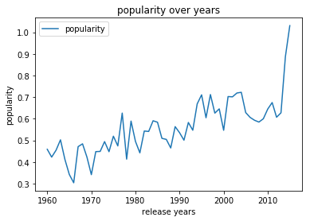

```python
# popularity trends over years
trends('popularity')
```

we can see the popularity is growing gradually from decade to decade but the peak is in the year **2015**.This trend is reasonable because of the advancement of the technology.In this Internet era we can find a movie by searching it in google,visiting some websites.

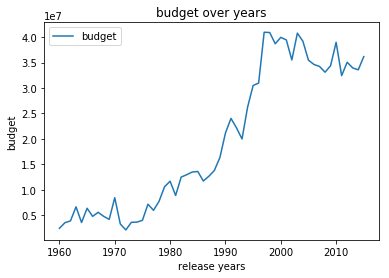

```python
# Budget trends over years
trends('budget')
```

The growth of the budget is gradual untill **1990's** and then it started growing exponentially.The movie with the highest budget is released in **2010** which is seen in the plot by a peak right at **2010**. Lets see the movies with highest budget to have a clear idea about the plot.

```python
tmdb.sort_values(by=['budget'],ascending=False).head(10)
```

|  | id | imdb_id | popularity | budget | revenue | profit | original_title | cast | director | runtime | genres | production_companies | release_date | vote_count | vote_average | release_year |
| --- | --- | --- | --- | --- | --- | --- | --- | --- | --- | --- | --- | --- | --- | --- | --- | --- |
| 2244 | 46528 | tt1032751 | 0.250540 | 425000000.0 | 1.108757e+07 | -4.139124e+08 | The Warrior's Way | Kate Bosworth\|Jang Dong-gun\|Geoffrey Rush\|Dann... | Sngmoo Lee | 100.0 | Adventure\|Fantasy\|Action\|Western\|Thriller | Boram Entertainment Inc. | 02/12/2010 | 74 | 6.4 | 2010 |
| 3375 | 1865 | tt1298650 | 4.955130 | 380000000.0 | 1.021683e+09 | 6.416830e+08 | Pirates of the Caribbean: On Stranger Tides | Johnny Depp\|PenÃ©lope Cruz\|Geoffrey Rush\|Ian M... | Rob Marshall | 136.0 | Adventure\|Action\|Fantasy | Walt Disney Pictures\|Jerry Bruckheimer Films\|M... | 11/05/2011 | 3180 | 6.3 | 2011 |
| 7387 | 285 | tt0449088 | 4.965391 | 300000000.0 | 9.610000e+08 | 6.610000e+08 | Pirates of the Caribbean: At World's End | Johnny Depp\|Orlando Bloom\|Keira Knightley\|Geof... | Gore Verbinski | 169.0 | Adventure\|Fantasy\|Action | Walt Disney Pictures\|Jerry Bruckheimer Films\|S... | 19/05/2007 | 2626 | 6.8 | 2007 |
| 14 | 99861 | tt2395427 | 5.944927 | 280000000.0 | 1.405036e+09 | 1.125036e+09 | Avengers: Age of Ultron | Robert Downey Jr.\|Chris Hemsworth\|Mark Ruffalo... | Joss Whedon | 141.0 | Action\|Adventure\|Science Fiction | Marvel Studios\|Prime Focus\|Revolution Sun Studios | 22/04/2015 | 4304 | 7.4 | 2015 |
| 6570 | 1452 | tt0348150 | 1.957331 | 270000000.0 | 3.910812e+08 | 1.210812e+08 | Superman Returns | Brandon Routh\|Kevin Spacey\|Kate Bosworth\|James... | Bryan Singer | 154.0 | Adventure\|Fantasy\|Action\|Science Fiction | DC Comics\|Legendary Pictures\|Warner Bros.\|Bad ... | 28/06/2006 | 834 | 5.3 | 2006 |
| 4411 | 49529 | tt0401729 | 1.588457 | 260000000.0 | 2.841391e+08 | 2.413910e+07 | John Carter | Taylor Kitsch\|Lynn Collins\|Mark Strong\|Willem ... | Andrew Stanton | 132.0 | Action\|Adventure\|Fantasy\|Science Fiction | Walt Disney Pictures | 07/03/2012 | 1479 | 6.0 | 2012 |
| 1929 | 38757 | tt0398286 | 2.865684 | 260000000.0 | 5.917949e+08 | 3.317949e+08 | Tangled | Zachary Levi\|Mandy Moore\|Donna Murphy\|Ron Perl... | Nathan Greno\|Byron Howard | 100.0 | Animation\|Family | Walt Disney Pictures\|Walt Disney Animation Stu... | 24/11/2010 | 2019 | 7.3 | 2010 |
| 7394 | 559 | tt0413300 | 2.520912 | 258000000.0 | 8.908716e+08 | 6.328716e+08 | Spider-Man 3 | Tobey Maguire\|Kirsten Dunst\|James Franco\|Thoma... | Sam Raimi | 139.0 | Fantasy\|Action\|Adventure | Columbia Pictures\|Laura Ziskin Productions\|Mar... | 01/05/2007 | 2083 | 5.8 | 2007 |
| 5508 | 57201 | tt1210819 | 1.214510 | 255000000.0 | 8.928991e+07 | -1.657101e+08 | The Lone Ranger | Johnny Depp\|Armie Hammer\|William Fichtner\|Hele... | Gore Verbinski | 149.0 | Action\|Adventure\|Western | Walt Disney Pictures\|Jerry Bruckheimer Films\|I... | 03/07/2013 | 1607 | 6.0 | 2013 |
| 1389 | 767 | tt0417741 | 5.076472 | 250000000.0 | 9.339592e+08 | 6.839592e+08 | Harry Potter and the Half-Blood Prince | Daniel Radcliffe\|Rupert Grint\|Emma Watson\|Tom ... | David Yates | 153.0 | Adventure\|Fantasy\|Family | Warner Bros.\|Heyday Films | 07/07/2009 | 3220 | 7.3 | 2009 |

We can see from the above table that the movies with the highest budgets are released between years 2000 and 2015

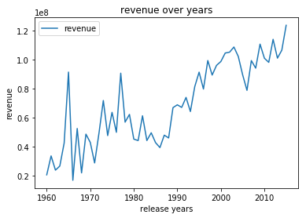

```python
# Revenue trends over years
trends('revenue')
```

Though the revenue is increasing gradually with years but there are some years with high revenue which may be **1965** and **1976** .

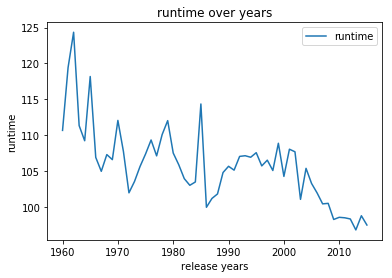

```python
# Runtime trends over years
trends('runtime')
```

It isn't surprising that the runtime has decreased over years and it is around **100 minutes** these days.

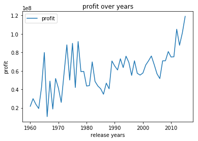

```python
# Profit trends over years
trends('profit')
```

Though some movies released in the 1900's have high profits,The trend has increased over years reaching the peak value in **2015** .

### Research Question 2 (Properties associated with the profitable movies:)

```python
top_500=tmdb.sort_values(by=['profit'],ascending=False).head(500).reset_index(drop=True)
top_500=pd.DataFrame(top_500)
top_500
```

|  | id | imdb_id | popularity | budget | revenue | profit | original_title | cast | director | runtime | genres | production_companies | release_date | vote_count | vote_average | release_year |
| --- | --- | --- | --- | --- | --- | --- | --- | --- | --- | --- | --- | --- | --- | --- | --- | --- |
| 0 | 19995 | tt0499549 | 9.432768 | 237000000.0 | 2.781506e+09 | 2.544506e+09 | Avatar | Sam Worthington\|Zoe Saldana\|Sigourney Weaver\|S... | James Cameron | 162.0 | Action\|Adventure\|Fantasy\|Science Fiction | Ingenious Film Partners\|Twentieth Century Fox ... | 10/12/2009 | 8458 | 7.1 | 2009 |
| 1 | 140607 | tt2488496 | 11.173104 | 200000000.0 | 2.068178e+09 | 1.868178e+09 | Star Wars: The Force Awakens | Harrison Ford\|Mark Hamill\|Carrie Fisher\|Adam D... | J.J. Abrams | 136.0 | Action\|Adventure\|Science Fiction\|Fantasy | Lucasfilm\|Truenorth Productions\|Bad Robot | 15/12/2015 | 5292 | 7.5 | 2015 |
| 2 | 597 | tt0120338 | 4.355219 | 200000000.0 | 1.845034e+09 | 1.645034e+09 | Titanic | Kate Winslet\|Leonardo DiCaprio\|Frances Fisher\|... | James Cameron | 194.0 | Drama\|Romance\|Thriller | Paramount Pictures\|Twentieth Century Fox Film ... | 18/11/1997 | 4654 | 7.3 | 1997 |
| 3 | 135397 | tt0369610 | 32.985763 | 150000000.0 | 1.513529e+09 | 1.363529e+09 | Jurassic World | Chris Pratt\|Bryce Dallas Howard\|Irrfan Khan\|Vi... | Colin Trevorrow | 124.0 | Action\|Adventure\|Science Fiction\|Thriller | Universal Studios\|Amblin Entertainment\|Legenda... | 09/06/2015 | 5562 | 6.5 | 2015 |
| 4 | 168259 | tt2820852 | 9.335014 | 190000000.0 | 1.506249e+09 | 1.316249e+09 | Furious 7 | Vin Diesel\|Paul Walker\|Jason Statham\|Michelle ... | James Wan | 137.0 | Action\|Crime\|Thriller | Universal Pictures\|Original Film\|Media Rights ... | 01/04/2015 | 2947 | 7.3 | 2015 |
| 5 | 24428 | tt0848228 | 7.637767 | 220000000.0 | 1.519558e+09 | 1.299558e+09 | The Avengers | Robert Downey Jr.\|Chris Evans\|Mark Ruffalo\|Chr... | Joss Whedon | 143.0 | Science Fiction\|Action\|Adventure | Marvel Studios | 25/04/2012 | 8903 | 7.3 | 2012 |
| 6 | 12445 | tt1201607 | 5.711315 | 125000000.0 | 1.327818e+09 | 1.202818e+09 | Harry Potter and the Deathly Hallows: Part 2 | Daniel Radcliffe\|Rupert Grint\|Emma Watson\|Alan... | David Yates | 130.0 | Adventure\|Family\|Fantasy | Warner Bros.\|Heyday Films\|Moving Picture Compa... | 07/07/2011 | 3750 | 7.7 | 2011 |
| 7 | 99861 | tt2395427 | 5.944927 | 280000000.0 | 1.405036e+09 | 1.125036e+09 | Avengers: Age of Ultron | Robert Downey Jr.\|Chris Hemsworth\|Mark Ruffalo... | Joss Whedon | 141.0 | Action\|Adventure\|Science Fiction | Marvel Studios\|Prime Focus\|Revolution Sun Studios | 22/04/2015 | 4304 | 7.4 | 2015 |
| 8 | 109445 | tt2294629 | 6.112766 | 150000000.0 | 1.274219e+09 | 1.124219e+09 | Frozen | Kristen Bell\|Idina Menzel\|Jonathan Groff\|Josh ... | Chris Buck\|Jennifer Lee | 102.0 | Animation\|Adventure\|Family | Walt Disney Pictures\|Walt Disney Animation Stu... | 27/11/2013 | 3369 | 7.5 | 2013 |
| 9 | 1642 | tt0113957 | 1.136610 | 22000000.0 | 1.106280e+09 | 1.084280e+09 | The Net | Sandra Bullock\|Jeremy Northam\|Dennis Miller\|We... | Irwin Winkler | 114.0 | Crime\|Drama\|Mystery\|Thriller\|Action | Columbia Pictures | 28/07/1995 | 201 | 5.6 | 1995 |
| 10 | 211672 | tt2293640 | 7.404165 | 74000000.0 | 1.156731e+09 | 1.082731e+09 | Minions | Sandra Bullock\|Jon Hamm\|Michael Keaton\|Allison... | Kyle Balda\|Pierre Coffin | 91.0 | Family\|Animation\|Adventure\|Comedy | Universal Pictures\|Illumination Entertainment | 17/06/2015 | 2893 | 6.5 | 2015 |
| 11 | 122 | tt0167260 | 7.122455 | 94000000.0 | 1.118889e+09 | 1.024889e+09 | The Lord of the Rings: The Return of the King | Elijah Wood\|Ian McKellen\|Viggo Mortensen\|Liv T... | Peter Jackson | 201.0 | Adventure\|Fantasy\|Action | WingNut Films\|New Line Cinema | 01/12/2003 | 5636 | 7.9 | 2003 |
| 12 | 68721 | tt1300854 | 4.946136 | 200000000.0 | 1.215440e+09 | 1.015440e+09 | Iron Man 3 | Robert Downey Jr.\|Gwyneth Paltrow\|Guy Pearce\|D... | Shane Black | 130.0 | Action\|Adventure\|Science Fiction | Marvel Studios | 18/04/2013 | 6882 | 6.9 | 2013 |
| 13 | 38356 | tt1399103 | 0.760503 | 195000000.0 | 1.123747e+09 | 9.287470e+08 | Transformers: Dark of the Moon | Shia LaBeouf\|John Malkovich\|Ken Jeong\|Frances ... | Michael Bay | 154.0 | Action\|Science Fiction\|Adventure | Paramount Pictures\|Di Bonaventura Pictures\|Has... | 28/06/2011 | 2456 | 6.1 | 2011 |
| 14 | 37724 | tt1074638 | 5.603587 | 200000000.0 | 1.108561e+09 | 9.085610e+08 | Skyfall | Daniel Craig\|Judi Dench\|Javier Bardem\|Ralph Fi... | Sam Mendes | 143.0 | Action\|Adventure\|Thriller | Columbia Pictures | 25/10/2012 | 6137 | 6.8 | 2012 |
| 15 | 93456 | tt1690953 | 3.928789 | 76000000.0 | 9.707619e+08 | 8.947619e+08 | Despicable Me 2 | Steve Carell\|Kristen Wiig\|Benjamin Bratt\|Miran... | Pierre Coffin\|Chris Renaud | 98.0 | Animation\|Comedy\|Family | Universal Pictures\|Illumination Entertainment | 25/06/2013 | 3436 | 7.0 | 2013 |
| 16 | 58 | tt0383574 | 4.205992 | 200000000.0 | 1.065660e+09 | 8.656598e+08 | Pirates of the Caribbean: Dead Man's Chest | Johnny Depp\|Orlando Bloom\|Keira Knightley\|Bill... | Gore Verbinski | 151.0 | Adventure\|Fantasy\|Action | Walt Disney Pictures\|Jerry Bruckheimer Films\|S... | 20/06/2006 | 3181 | 6.8 | 2006 |
| 17 | 10193 | tt0435761 | 2.711136 | 200000000.0 | 1.063172e+09 | 8.631719e+08 | Toy Story 3 | Tom Hanks\|Tim Allen\|Ned Beatty\|Joan Cusack\|Mic... | Lee Unkrich | 103.0 | Animation\|Family\|Comedy | Walt Disney Pictures\|Pixar Animation Studios | 16/06/2010 | 2924 | 7.5 | 2010 |
| 18 | 329 | tt0107290 | 2.204926 | 63000000.0 | 9.201000e+08 | 8.571000e+08 | Jurassic Park | Sam Neill\|Laura Dern\|Jeff Goldblum\|Richard Att... | Steven Spielberg | 127.0 | Adventure\|Science Fiction | Universal Pictures\|Amblin Entertainment | 11/06/1993 | 3169 | 7.4 | 1993 |
| 19 | 671 | tt0241527 | 8.021423 | 125000000.0 | 9.764756e+08 | 8.514756e+08 | Harry Potter and the Philosopher's Stone | Daniel Radcliffe\|Rupert Grint\|Emma Watson\|John... | Chris Columbus | 152.0 | Adventure\|Fantasy\|Family | 1492 Pictures\|Warner Bros.\|Heyday Films | 16/11/2001 | 4265 | 7.2 | 2001 |
| 20 | 121 | tt0167261 | 8.095275 | 79000000.0 | 9.262874e+08 | 8.472874e+08 | The Lord of the Rings: The Two Towers | Elijah Wood\|Ian McKellen\|Viggo Mortensen\|Liv T... | Peter Jackson | 179.0 | Adventure\|Fantasy\|Action | WingNut Films\|New Line Cinema\|The Saul Zaentz ... | 18/12/2002 | 5114 | 7.8 | 2002 |
| 21 | 49026 | tt1345836 | 6.591277 | 250000000.0 | 1.081041e+09 | 8.310413e+08 | The Dark Knight Rises | Christian Bale\|Michael Caine\|Gary Oldman\|Anne ... | Christopher Nolan | 165.0 | Action\|Crime\|Drama\|Thriller | Legendary Pictures\|Warner Bros.\|DC Entertainme... | 16/07/2012 | 6723 | 7.5 | 2012 |
| 22 | 12155 | tt1014759 | 5.572950 | 200000000.0 | 1.025467e+09 | 8.254671e+08 | Alice in Wonderland | Mia Wasikowska\|Johnny Depp\|Anne Hathaway\|Helen... | Tim Burton | 108.0 | Family\|Fantasy\|Adventure | Walt Disney Pictures\|Team Todd\|Tim Burton Prod... | 03/03/2010 | 2853 | 6.3 | 2010 |
| 23 | 155 | tt0468569 | 8.466668 | 185000000.0 | 1.001922e+09 | 8.169218e+08 | The Dark Knight | Christian Bale\|Michael Caine\|Heath Ledger\|Aaro... | Christopher Nolan | 152.0 | Drama\|Action\|Crime\|Thriller | DC Comics\|Legendary Pictures\|Warner Bros.\|Syncopy | 16/07/2008 | 8432 | 8.1 | 2008 |
| 24 | 1893 | tt0120915 | 3.526029 | 115000000.0 | 9.243176e+08 | 8.093176e+08 | Star Wars: Episode I - The Phantom Menace | Liam Neeson\|Ewan McGregor\|Natalie Portman\|Jake... | George Lucas | 136.0 | Adventure\|Action\|Science Fiction | Lucasfilm | 19/05/1999 | 2823 | 6.3 | 1999 |
| 25 | 8355 | tt1080016 | 3.154914 | 90000000.0 | 8.866868e+08 | 7.966868e+08 | Ice Age: Dawn of the Dinosaurs | Ray Romano\|John Leguizamo\|Denis Leary\|Queen La... | Carlos Saldanha | 94.0 | Animation\|Comedy\|Family\|Adventure | Blue Sky Studios\|Twentieth Century Fox Animation | 29/06/2009 | 1392 | 6.4 | 2009 |
| 26 | 675 | tt0373889 | 4.878162 | 150000000.0 | 9.382127e+08 | 7.882127e+08 | Harry Potter and the Order of the Phoenix | Daniel Radcliffe\|Rupert Grint\|Emma Watson\|Mich... | David Yates | 138.0 | Adventure\|Fantasy\|Family\|Mystery | Cool Music\|Warner Bros.\|Heyday Films\|Harry Pot... | 28/06/2007 | 3382 | 7.2 | 2007 |
| 27 | 601 | tt0083866 | 2.900556 | 10500000.0 | 7.929106e+08 | 7.824106e+08 | E.T. the Extra-Terrestrial | Henry Thomas\|Drew Barrymore\|Robert MacNaughton... | Steven Spielberg | 115.0 | Science Fiction\|Adventure\|Family\|Fantasy | Universal Pictures\|Amblin Entertainment | 03/04/1982 | 1830 | 7.2 | 1982 |
| 28 | 57800 | tt1667889 | 3.135776 | 95000000.0 | 8.772448e+08 | 7.822448e+08 | Ice Age: Continental Drift | John Leguizamo\|Ray Romano\|Chris Wedge\|Denis Le... | Steve Martino\|Mike Thurmeier | 88.0 | Animation\|Comedy\|Adventure\|Family | Blue Sky Studios\|Twentieth Century Fox Animation | 26/06/2012 | 1920 | 6.2 | 2012 |
| 29 | 120 | tt0120737 | 8.575419 | 93000000.0 | 8.713684e+08 | 7.783684e+08 | The Lord of the Rings: The Fellowship of the Ring | Elijah Wood\|Ian McKellen\|Viggo Mortensen\|Liv T... | Peter Jackson | 178.0 | Adventure\|Fantasy\|Action | WingNut Films\|New Line Cinema\|The Saul Zaentz ... | 18/12/2001 | 6079 | 7.8 | 2001 |
| ... | ... | ... | ... | ... | ... | ... | ... | ... | ... | ... | ... | ... | ... | ... | ... | ... |
| 470 | 11395 | tt0111070 | 1.259399 | 22000000.0 | 1.898334e+08 | 1.678334e+08 | The Santa Clause | Tim Allen\|Judge Reinhold\|Wendy Crewson\|David K... | John Pasquin | 97.0 | Fantasy\|Drama\|Comedy\|Family | Walt Disney Pictures\|Hollywood Pictures | 10/11/1994 | 274 | 6.3 | 1994 |
| 471 | 11970 | tt0119282 | 3.488910 | 85000000.0 | 2.527121e+08 | 1.677121e+08 | Hercules | Tate Donovan\|Josh Keaton\|Roger Bart\|Danny DeVi... | John Musker\|Ron Clements | 93.0 | Animation\|Family\|Fantasy\|Adventure\|Comedy | Walt Disney Pictures | 26/06/1997 | 909 | 7.0 | 1997 |
| 472 | 699 | tt0082398 | 1.771093 | 28000000.0 | 1.953128e+08 | 1.673128e+08 | For Your Eyes Only | Roger Moore\|Carole Bouquet\|Chaim Topol\|Lynn-Ho... | John Glen | 127.0 | Adventure\|Action\|Thriller | Eon Productions\|Metro-Goldwyn-Mayer (MGM) | 23/06/1981 | 268 | 6.0 | 1981 |
| 473 | 20943 | tt1142988 | 1.860267 | 38000000.0 | 2.052989e+08 | 1.672989e+08 | The Ugly Truth | Katherine Heigl\|Gerard Butler\|Eric Winter\|Bree... | Robert Luketic | 96.0 | Comedy\|Romance | Lakeshore Entertainment\|Relativity Media | 24/07/2009 | 584 | 6.3 | 2009 |
| 474 | 10137 | tt0164912 | 1.309249 | 133000000.0 | 3.001354e+08 | 1.671354e+08 | Stuart Little | Michael J. Fox\|Geena Davis\|Hugh Laurie\|Jonatha... | Rob Minkoff | 84.0 | Fantasy | Columbia Pictures Corporation\|Global Medien KG... | 17/12/1999 | 502 | 5.6 | 1999 |
| 475 | 76203 | tt2024544 | 3.625529 | 20000000.0 | 1.870000e+08 | 1.670000e+08 | 12 Years a Slave | Chiwetel Ejiofor\|Michael Fassbender\|Lupita Nyo... | Steve McQueen | 134.0 | Drama\|History | Plan B Entertainment\|Regency Enterprises\|River... | 18/10/2013 | 2241 | 7.9 | 2013 |
| 476 | 1493 | tt0212346 | 1.073638 | 45000000.0 | 2.120000e+08 | 1.670000e+08 | Miss Congeniality | Sandra Bullock\|Benjamin Bratt\|Michael Caine\|Ca... | Donald Petrie | 111.0 | Comedy\|Crime\|Action | Village Roadshow Pictures\|Castle Rock Entertai... | 14/12/2000 | 563 | 6.1 | 2000 |
| 477 | 109418 | tt2191701 | 1.447973 | 80000000.0 | 2.469843e+08 | 1.669843e+08 | Grown Ups 2 | Adam Sandler\|Kevin James\|Chris Rock\|David Spad... | Dennis Dugan | 100.0 | Comedy | Columbia Pictures\|Happy Madison Productions\|So... | 11/07/2013 | 806 | 5.9 | 2013 |
| 478 | 4982 | tt0765429 | 1.946073 | 100000000.0 | 2.664650e+08 | 1.664650e+08 | American Gangster | Denzel Washington\|Russell Crowe\|Chiwetel Ejiof... | Ridley Scott | 157.0 | Drama\|Crime | Imagine Entertainment\|Universal Pictures\|Scott... | 02/11/2007 | 966 | 7.3 | 2007 |
| 479 | 75612 | tt1483013 | 4.405923 | 120000000.0 | 2.861686e+08 | 1.661686e+08 | Oblivion | Tom Cruise\|Morgan Freeman\|Olga Kurylenko\|Andre... | Joseph Kosinski | 126.0 | Action\|Science Fiction\|Adventure\|Mystery | Universal Pictures\|Chernin Entertainment\|Relat... | 10/04/2013 | 3729 | 6.3 | 2013 |
| 480 | 72570 | tt1606389 | 1.821562 | 30000000.0 | 1.961146e+08 | 1.661146e+08 | The Vow | Rachel McAdams\|Channing Tatum\|Sam Neill\|Scott ... | Michael Sucsy | 104.0 | Drama\|Romance | Spyglass Entertainment\|Screen Gems | 05/02/2012 | 861 | 6.9 | 2012 |
| 481 | 754 | tt0119094 | 1.330225 | 80000000.0 | 2.456761e+08 | 1.656761e+08 | Face/Off | John Travolta\|Nicolas Cage\|Joan Allen\|Alessand... | John Woo | 138.0 | Action\|Crime\|Science Fiction\|Thriller | Paramount Pictures\|Permut Presentations\|WCG En... | 27/06/1997 | 955 | 6.7 | 1997 |
| 482 | 820 | tt0102138 | 0.658866 | 40000000.0 | 2.054055e+08 | 1.654055e+08 | JFK | Kevin Costner\|Tommy Lee Jones\|Gary Oldman\|Kevi... | Oliver Stone | 189.0 | Drama\|Thriller\|History | Camelot Productions\|Canal Plus Group\|Ixtlan Pr... | 20/12/1991 | 258 | 7.2 | 1991 |
| 483 | 2064 | tt0114924 | 1.068338 | 17000000.0 | 1.820570e+08 | 1.650570e+08 | While You Were Sleeping | Sandra Bullock\|Bill Pullman\|Peter Gallagher\|Pe... | Jon Turteltaub | 103.0 | Comedy\|Drama\|Romance | Caravan Pictures\|Hollywood Pictures | 21/04/1995 | 169 | 6.2 | 1995 |
| 484 | 32856 | tt0817230 | 1.145806 | 52000000.0 | 2.164857e+08 | 1.644857e+08 | Valentine's Day | Jessica Alba\|Jessica Biel\|Bradley Cooper\|Eric ... | Garry Marshall | 125.0 | Comedy\|Romance | New Line Cinema\|Karz Entertainment\|Rice Films | 10/02/2010 | 675 | 5.6 | 2010 |
| 485 | 9982 | tt0371606 | 1.766397 | 150000000.0 | 3.144327e+08 | 1.644327e+08 | Chicken Little | Zach Braff\|Garry Marshall\|Don Knotts\|Patrick S... | Mark Dindal | 81.0 | Animation\|Family\|Comedy | Walt Disney Pictures\|Walt Disney Feature Anima... | 04/11/2005 | 542 | 5.6 | 2005 |
| 486 | 142 | tt0388795 | 1.475604 | 14000000.0 | 1.780438e+08 | 1.640438e+08 | Brokeback Mountain | Heath Ledger\|Jake Gyllenhaal\|Randy Quaid\|Miche... | Ang Lee | 134.0 | Drama\|Romance | River Road Entertainment\|Alberta Film Entertai... | 02/09/2005 | 780 | 7.2 | 2005 |
| 487 | 628 | tt0110148 | 2.064440 | 60000000.0 | 2.236646e+08 | 1.636646e+08 | Interview with the Vampire | Brad Pitt\|Tom Cruise\|Kirsten Dunst\|Antonio Ban... | Neil Jordan | 123.0 | Horror\|Romance | Geffen Pictures | 11/11/1994 | 829 | 7.0 | 1994 |
| 488 | 10663 | tt0120484 | 1.053252 | 23000000.0 | 1.859916e+08 | 1.629916e+08 | The Waterboy | Adam Sandler\|Kathy Bates\|Fairuza Balk\|Henry Wi... | Frank Coraci | 90.0 | Comedy | Touchstone Pictures | 06/11/1998 | 292 | 5.8 | 1998 |
| 489 | 224141 | tt2180411 | 2.996038 | 50000000.0 | 2.129024e+08 | 1.629024e+08 | Into the Woods | Meryl Streep\|Emily Blunt\|James Corden\|Anna Ken... | Rob Marshall | 125.0 | Fantasy\|Comedy\|Music | Walt Disney Pictures\|Marc Platt Productions\|Lu... | 25/12/2014 | 1095 | 5.6 | 2014 |
| 490 | 533 | tt0312004 | 1.212451 | 30000000.0 | 1.924528e+08 | 1.624528e+08 | The Curse of the Were-Rabbit | Peter Sallis\|Helena Bonham Carter\|Ralph Fienne... | Steve Box\|Nick Park | 85.0 | Adventure\|Animation\|Comedy\|Family | Aardman Animations\|DreamWorks Animation | 04/09/2005 | 373 | 6.6 | 2005 |
| 491 | 10198 | tt0780521 | 2.463982 | 105000000.0 | 2.670458e+08 | 1.620458e+08 | The Princess and the Frog | Anika Noni Rose\|Bruno Campos\|Keith David\|Micha... | Ron Clements\|John Musker | 97.0 | Romance\|Family\|Animation\|Music | Walt Disney Pictures\|Walt Disney Animation Stu... | 08/12/2009 | 706 | 6.5 | 2009 |
| 492 | 81188 | tt1446192 | 1.832434 | 145000000.0 | 3.069417e+08 | 1.619417e+08 | Rise of the Guardians | Chris Pine\|Alec Baldwin\|Jude Law\|Isla Fisher\|H... | Peter Ramsey | 97.0 | Fantasy\|Animation\|Family | DreamWorks Animation | 21/11/2012 | 1272 | 6.9 | 2012 |
| 493 | 2907 | tt0101272 | 0.983036 | 30000000.0 | 1.915024e+08 | 1.615024e+08 | The Addams Family | Raúl Juliá\|Anjelica Huston\|Christopher Lloyd... | Barry Sonnenfeld | 99.0 | Comedy\|Family\|Fantasy | Paramount Pictures\|Orion Pictures\|Scott Rudin ... | 22/11/1991 | 414 | 6.6 | 1991 |
| 494 | 7840 | tt0443649 | 1.841839 | 105000000.0 | 2.660000e+08 | 1.610000e+08 | 10,000 BC | Steven Strait\|Camilla Belle\|Cliff Curtis\|Natha... | Roland Emmerich | 109.0 | Adventure\|Action\|Drama\|Fantasy | Centropolis Entertainment\|Legendary Pictures\|W... | 22/02/2008 | 586 | 5.2 | 2008 |
| 495 | 9798 | tt0120660 | 1.303667 | 90000000.0 | 2.506498e+08 | 1.606498e+08 | Enemy of the State | Will Smith\|Gene Hackman\|Jon Voight\|Lisa Bonet\|... | Tony Scott | 132.0 | Action\|Drama\|Thriller | Jerry Bruckheimer Films\|Scott Free Productions... | 20/11/1998 | 815 | 6.5 | 1998 |
| 496 | 584 | tt0322259 | 0.723225 | 76000000.0 | 2.363507e+08 | 1.603507e+08 | 2 Fast 2 Furious | Paul Walker\|Tyrese Gibson\|Eva Mendes\|Cole Haus... | John Singleton | 107.0 | Action\|Crime\|Thriller | Mikona Productions GmbH & Co. KG\|Universal Pic... | 05/06/2003 | 1275 | 6.1 | 2003 |
| 497 | 77930 | tt1915581 | 1.974672 | 7000000.0 | 1.672216e+08 | 1.602216e+08 | Magic Mike | Channing Tatum\|Matthew McConaughey\|Olivia Munn... | Steven Soderbergh | 110.0 | Drama\|Comedy | Nick Wechsler Productions\|Extension 765 | 28/06/2012 | 664 | 6.1 | 2012 |
| 498 | 13053 | tt0397892 | 1.480497 | 150000000.0 | 3.099800e+08 | 1.599800e+08 | Bolt | John Travolta\|Miley Cyrus\|Susie Essman\|Mark Wa... | Chris Williams\|Byron Howard | 96.0 | Animation\|Family\|Adventure\|Comedy | Walt Disney Pictures\|Walt Disney Animation Stu... | 20/11/2008 | 1119 | 6.3 | 2008 |
| 499 | 1995 | tt0146316 | 2.179727 | 115000000.0 | 2.747033e+08 | 1.597033e+08 | Lara Croft: Tomb Raider | Angelina Jolie\|Jon Voight\|Iain Glen\|Noah Taylo... | Simon West | 100.0 | Adventure\|Fantasy\|Action\|Thriller | Paramount Pictures\|Toho-Towa\|Mutual Film Compa... | 11/06/2001 | 1510 | 5.6 | 2001 |

500 rows × 16 columns

Now I will consider the dataframe **top_500** to be my data for furthur data analysis.

#### Average Budget of profited movies:

```python
top_500['budget'].mean()
```

```
89741580.0
```

The average **budget** of top 500 profited movies is *89.7 million US dollars*.

#### Average Runtime of profited movies:

```python
top_500['runtime'].mean()
```

```
117.754
```

The average **runtime** of top 500 profited movies is approximately *117 minutes*.

#### Average revenue of profited movies:

```python
top_500['revenue'].mean()
```

```
454459804.738
```

The average **revenue** of top 500 profited movies is nearly *454 million US dollars* which is much greater than the average budget.Its not suprising because we are talking about most profited movies here.

#### Successful Directors:

This is estimated by taking the directors with the most movies in the profited movies data.

```python
# I will take a method to do this estimation:
def find_best(column):
    best_list = column.str.cat(sep='|').split('|')
    #transfer it to a dataframe
    dic = pd.DataFrame({'top' :best_list})
    #count their number of appeared times and
    #choose the top3
    best =pd.DataFrame(dic['top'].value_counts().head(3))
    return best
```

```python
# Top 3 successful directors
find_best(top_500['director'])
```

|  | top |
| --- | --- |
| Steven Spielberg | 16 |
| Peter Jackson | 7 |
| Ron Howard | 6 |

So,We can say that these 3 directors are the most repeated and also the most popular directors in hollywood as they are the most repeated directors meaning the most promising directors.**Steven spielberg** is undoubtfully one of the best directors and also the most popular.

#### Successful Genres:

```python
# top 3 successful Genres
find_best(top_500['genres'])
```

|  | top |
| --- | --- |
| Action | 210 |
| Adventure | 208 |
| Comedy | 168 |

We can see that action genre is the most liked genre and has been in so many movies.

#### Successful Cast:

```python
# top 3 successful Cast
find_best(top_500['cast'])
```

|  | top |
| --- | --- |
| Tom Cruise | 16 |
| Tom Hanks | 14 |
| Bruce Willis | 13 |

I completely agree with this as I have seen a lots of **Tom cruise** which were blockbusters in boxoffice and the same with **Tom Hanks** and **Bruce Willis**.

#### Successful production companies:

```python
# Top 3 successful production companies
find_best(top_500['production_companies'])
```

|  | top |
| --- | --- |
| Warner Bros. | 64 |
| Universal Pictures | 59 |
| Paramount Pictures | 55 |

Its no doubt that *Warner Bros.* tops this list as it has produced many amazing movies.

### Research Question 3 (Correlations:)

#### Runtime Vs Popularity:

I wanted to analyse the correlation between runtime and popularity so that I could draw some conclusions.So I am going to draw a plot with runtime and popularity on both axes.

```python
# A method to draw this plot
def correlate(column1,column2):
    plt.scatter(year_trend[column1],year_trend[column2])
    plt.xlabel(column1)
    plt.ylabel(column2)
    plt.title('{} vs {} over years'.format(column1,column2))
    plt.show()
```

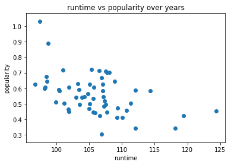

```python
# plot for runtime vs popularity
correlate('runtime','popularity')
```

It looks like runtime and popularity are inversely propotional though we cant be sure about it.

#### Revenue VS Popularity:

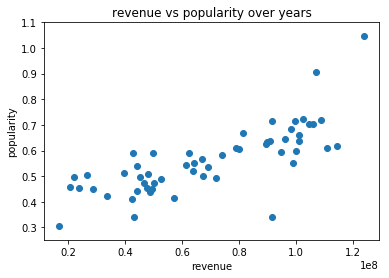

```python
correlate('revenue','popularity')
```

It looks like revenue and popularity are directly propotional but we can see that some of the movies with high revenues are not so popular.

#### Budget VS Profit:

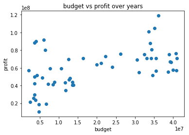

```python
correlate('budget','profit')
```

We can see that budget and profit are not correlated as you can see many samples not folllowing any correlation but on a overview we can see that they are positively correlated.

## Limitations

- We assumed the **revenue** and **budget** columns to be in us dollars.Any difference in the currencies are ignored.
- We had discarded some columns hoping they might not be useful in the analysis.But We cannot be sure about that.
- We have converted some rows with 0 in it them to null in the data cleaning process.
- The medium and method used to calculate the popularity are unknown.
- There are many assumptions and limitations which are to be obeyed throughout the analysis.
- In the second and third explorations I have used the data of top 500 profited movies.This may not be best way to do it and it may contain some errors.
- I clearly mention that all my findings are *Tentative* as I have not used machine learning or statistical tests in this project.

## Conclusions

### General Questions

- In this part we explored some general questions.It has been found that The movie with the highest profit is **'avatar'** and least profit is **'The Warrior's Way'**,with highest budget is **'The Warrior's Way'** and least budget is **'Fear Clinic'**,with the highest revenue is **'avatar'** and least revenue is **'shattered glass'** .
- It has been found that the year *2015* is the year with most profited movies counting to **19 billion dollars**.
- The *popularity,budget,revenue and profits* have a growing trends over years.But the *runtime* decreased from 125 to 100 over years.

### Correlations

- **Runtime** and **popularity** have *Negative correlation* over years.
- **Revenue** and **Popularity** have *Positive correlation* over years.
- **Budget** and **profit** have *Positive correlation* over years but the movies that don't stick to this are more in number.
- Note- *correlation doesnot imply causation* for example If a movie earns a good profit doesnt mean that it is due to its high budget just because profit and budget are positively correlated.This analysis does not state or imply that one change causes another based solely on a correlation.